# Pf cheater phage manuscript figures

Nanami Kubota

Last updated: 2025-08-10

# 1 Load libraries and color palette

Load libraries

```r
library(tidyverse)
library(growthcurver) #growth curve calculations
library(reshape2)
library(gggenes) #gene map
library(ggrepel)
library(stringr)
library(scales)
library(colorspace) #needed for darkening text color
library(viridis) #color gradient
library(ggstar) #adds star to ggplot (for pf5r mutants)
library(ggh4x)
library(ggnewscale) #add multiple scale colors
library(ggpubr) #add significance to plot
library(rstatix)
library(ggtext) #for bold/italics
library(ggpmisc)
```

Color table

```r
col_csv <- read.csv("./figures/color_table.csv", header = T) #generates warning but you can ignore this
col_hex <- setNames(object = col_csv$hex, nm=col_csv$strain)

col_hex2 <- col_hex
names(col_hex2)[1] <- "PA14 WT"
names(col_hex2)[4] <- "PA14 WT "
```

# 2 Read depth figure

## 2.1 Prepare data

### 2.1.1 Load data

Gather read depth data for individual clones

```r
#PA14 WT
wt <- read.delim("./read_depth/data/PA14WT_cov_10.txt", col.names = c("n","start","end","read_depth"))
wt$id <- "wt"

#PA14*full
f <- read.delim("./read_depth/data/B1_PA14_full_cov_10.txt", col.names = c("n","start","end","read_depth"))
f$id <- "f"

#PA14*full/mini
fm <- read.delim("./read_depth/data/new_G1_PA14_full_mini_cov_10.txt", col.names = c("n","start","end","read_depth"))
fm$id <- "fm"

#PA14*mini
m <- read.delim("./read_depth/data/Pf5_cap_del_1_PA14_mini_cov_10.txt", col.names = c("n","start","end","read_depth"))
m$id <- "m"

#PA14delPf5
delPf5 <- read.delim("./read_depth/data/delPf5_PA14_del_Pf5_cov_10.txt", col.names = c("n","start","end","read_depth"))
delPf5$id <- "delPf5"

rd <- rbind(wt, f, fm, m, delPf5)
```

Read depth for evolved population

```r
pop5 <- read.delim("./read_depth/data/plank_no_drug_pop5_day12_SRR13453461_cov_10.txt", col.names = c("n","start","end","read_depth"))
pop5$id <- "pop5"
```

### 2.1.2 calculate average

Pf circularization in new reference genome (as called by breseq): 4345098 - 4355762 Pf attL in new reference genome (10 bp): 4345098 - 4345107 Pf attR in new reference genome (10 bp): 4355763 - 4355772 Pf loss in new reference genome (as called by breseq): 4345107 - 4355773

Pf5 phage region (including attL and attR): 4345098-4355772

Calculate average read depth 1kb upstream of Pf5 in all strains (do not include att sites) - upstream of Pf5 region: 4344097 - 4345097 - downstream of Pf5 region: 4355773 - 4356773

```r
up_rd <- rd[which(rd$end < 4345097 & rd$end >= 4344097),] #subset 1kb for all strain; 100 measurements of 10bp windows per strain

up_rd_avg <- up_rd %>%
  group_by(id) %>%
  summarise_at(vars(read_depth), list(up_avg = mean))
```

Calculate average read depth 1kb downstream of Pf5 in all strains

```r
down_rd <- rd[which(rd$start >= 4355773 & rd$start < 4356773),] #subset 1kb for all strain; 100 measurements of 10bp windows per strain
down_rd_avg <- down_rd %>%
  group_by(id) %>%
  summarise_at(vars(read_depth), list(down_avg = mean))
```

Combine up and down average

```r
bac_avg <- merge(up_rd_avg, down_rd_avg, by="id")
```

Average by both up and down stream

```r
bac_avg$bac_avg <- rowMeans(bac_avg[,c("up_avg","down_avg")])
bac_avg
```

```
##       id  up_avg down_avg  bac_avg
## 1 delPf5  97.532   86.344  91.9380
## 2      f 112.607   93.095 102.8510
## 3     fm 241.547  260.427 250.9870
## 4      m 112.847  116.929 114.8880
## 5     wt 157.720  175.671 166.6955
```

Do for pop5

Calculate average read depth 1kb upstream of Pf5 in all strains

```r
up_pop5 <- pop5[which(pop5$end < 4345097 & pop5$end >= 4344097),] #subset 1kb for all strain; 100 measurements of 10bp windows per strain
up_pop5_avg <- up_pop5 %>%
  group_by(id) %>%
  summarise_at(vars(read_depth), list(up_avg = mean))
```

Calculate average read depth 1kb downstream of Pf5 in all strains

```r
down_pop5 <- pop5[which(pop5$start >= 4355773 & pop5$start < 4356773),] #subset 1kb for all strain; 100 measurements of 10bp windows per strain
down_pop5_avg <- down_pop5 %>%
  group_by(id) %>%
  summarise_at(vars(read_depth), list(down_avg = mean))
```

Combine up and down average

```r
pop5_avg <- merge(up_pop5_avg, down_pop5_avg, by="id")
```

Average by both up and down stream

```r
pop5_avg$pop5_avg <- rowMeans(pop5_avg[,c("up_avg","down_avg")])
```

### 2.1.3 ORF annotation

Annotation data

```r
#read annotation (from Pseudomonas Genome Database v21.1)
pa14 <- read.csv("./read_depth/Pseudomonas_aeruginosa_UCBPP-PA14_109.csv", header = T)

#subset pf5 + flanking genes
row1 <- which(pa14$Locus.Tag=="PA14_48870") #left side of pf5
row2 <- which(pa14$Locus.Tag=="PA14_49040") #right side of pf5

pf5 <- pa14[row1:row2,] #pf5 with flanking genes

#turn hypothetical proteins = NA for labeling purposes
pf5$label <- pf5$Product.Name #make a new column that is identical to the product column
pf5$label[which(pf5$Product.Name == "C32 tRNA thiolase")] <- "tRNA"
pf5$label[which(pf5$Product.Name == "bacteriophage integrase")] <- "integrase"
pf5$label[which(pf5$Locus.Tag == "PA14_48890")] <- "replication initiator"
pf5$label[which(pf5$Locus.Tag == "PA14_48910")] <- "zot"
pf5$label[which(pf5$Locus.Tag == "PA14_48990")] <- "pflM"
pf5$label[which(pf5$Product.Name == "bacteriophage protein")] <- "capsid"
pf5$label[which(pf5$Product.Name == "coat protein A of bacteriophage Pf1")] <- "capsid"
pf5$label[which(pf5$Product.Name == "coat protein B of bacteriophage Pf1)")] <- "capsid"
pf5$label[which(pf5$Locus.Tag == "PA14_48960")] <- "pfsE"
pf5$label[which(pf5$Product.Name == "helix destabilizing protein of bacteriophage Pf1")] <- "hypothetical protein"
pf5$label[which(pf5$Product.Name == "Pf5 prophage excisionase, XisF5")] <- "xisF5"
pf5$label[which(pf5$Product.Name == "Pf5 repressor C")] <- "pf5r"
for (i in 1:nrow(pf5)) {
  if(pf5$label[i]=="hypothetical protein"){
    pf5$label[i] <- NA
  }
}

#fix direction of ORF
pf5$new_start <- NA
pf5$new_end <- NA
pf5$label_position <- NA
for (j in 1:nrow(pf5)) {
  if(pf5$Strand[j] == "+"){
    pf5$new_start[j] <- pf5$Start[j]
    pf5$new_end[j] <- pf5$End[j]
  }else{
    pf5$new_start[j] <- pf5$End[j]
    pf5$new_end[j] <- pf5$Start[j]
  }
  pf5$label_position[j] <- mean(c(pf5$Start[j], pf5$End[j]))
}

#copy for evolved population
pf5_pop5 <- pf5
```

Multiply annotation by 5 to get individual gene maps and add id

```r
id_c <- c("annot", "wt", "f", "fm", "m", "delPf5")
pf5$id <- "annot"
pf5_6 <- pf5
for (i in 2:length(id_c)) {
  temp <- pf5
  temp$id <- id_c[i]
  pf5_6 <- rbind(pf5_6, temp)
}

# factor to change order
pf5_6$id <- factor(pf5_6$id, levels=c("annot", "wt", "f", "fm", "m", "delPf5"))

#remove labels from all but last one
pf5_6$label_text <- pf5_6$label
pf5_6[which(pf5_6$id != "annot"),"label_text"] <- NA
```

### 2.1.4 subset read depth to Pf5 prophage

```r
#subset coverage
range_min <- min(pf5_6$new_end) #find position of left side of genome
range_max <- max(pf5_6$new_end) #find position of the right side of genome
rd.sub <- rd[which(rd$start>=range_min & rd$end<=range_max),]
```

Do for pop5

```r
#subset coverage
range_min <- min(pf5_pop5$new_end) #find position of left side of genome
range_max <- max(pf5_pop5$new_end) #find position of the right side of genome
pop5.sub <- pop5[which(pop5$start>=range_min & pop5$end<=range_max),]
```

### 2.1.5 normalize read depth

```r
#average rd.sub by bac_avg dataframe
rd.sub$norm <- NA
for (i in 1:nrow(rd.sub)) {
  id_i <- rd.sub$id[i]
  b_avg <- bac_avg[which(bac_avg$id == id_i), "bac_avg"]
  rd.sub$norm[i] <- rd.sub$read_depth[i] / b_avg
}
```

Do for pop5

```r
#average rd.sub by bac_avg dataframe
pop5.sub$norm <- NA
for (i in 1:nrow(pop5.sub)) {
  id_i <- pop5.sub$id[i]
  b_pop5_avg <- pop5_avg[which(pop5_avg$id == id_i), "pop5_avg"]
  pop5.sub$norm[i] <- pop5.sub$read_depth[i] / b_pop5_avg
}
```

### 2.1.6 center gene map

```r
#center annotation map
pf5_6$r <- rep(c(0.75, 250, 1500, 20000, 75, 60), each=18)
r <- c(0.75, 250, 1500, 20000, 75, 60)


#for normalized maps
pf5_6$rnorm <- rep(c(0.75, 1.5, 12.5, 100, 0.75, 0.75), each=18)
rnorm <- c(0.75, 1.5, 12.5, 100, 0.75, 0.75)

#y limits
r_y_lim <- list(
  scale_y_continuous(limits = c(0, 2)),
  scale_y_continuous(limits = c(0, 600)),
  scale_y_continuous(labels=comma, limits = c(0, 3100)),
  scale_y_continuous(labels=comma, limits = c(0, 80000)),
  scale_y_continuous(limits = c(0, 150)),
  scale_y_continuous(limits = c(0, 150))
)
r_norm_y_lim <- list(
  scale_y_continuous(limits = c(0, 2)),
  scale_y_continuous(limits = c(0, 3.5)),
  scale_y_continuous(limits = c(0, 30)),
  scale_y_continuous(limits = c(0, 300)),
  scale_y_continuous(limits = c(0, 1.5)),
  scale_y_continuous(limits = c(0, 1.5))
)
```

### 2.1.7 gene colors

Color scheme

```r
pf5_6$label <- factor(pf5_6$label, levels = c("capsid", "integrase", "pf5r", "pfsE", "replication initiator", "tRNA", "xisF5", "zot", "pflM"))
pf_colors <- setNames(c("#66C2A5", "#FC8D62", "#8DA0CB", "#E78AC3", "#A6D854", "#FFD92F", "#E5C494", "grey40","#E41A1C"), levels(pf5_6$label))

pf5_pop5$label <- factor(pf5_pop5$label, levels = c("capsid", "integrase", "pf5r", "pfsE", "replication initiator", "tRNA", "xisF5", "zot", "pflM"))
pf_colors_pop5 <- setNames(c("#66C2A5", "#FC8D62", "#8DA0CB", "#E78AC3", "#A6D854", "#FFD92F", "#E5C494", "grey40","#E41A1C"), levels(pf5_pop5$label))
```

Remove annotation labels except for first facet

```r
pf5_6$locus_text <- pf5_6$Locus.Tag
pf5_6[which(pf5_6$id != "annot"),"locus_text"] <- NA
```

Add star for pf5r mutation

```r
#star symbol for pf5r mutation
pf5r_mut <- data.frame(x=rep(4353504, 3), r=c(1500, 20000, 75), rnorm=c(12.5, 100, 0.75), id=c("f", "fm", "m"))
```

## 2.2 figures

### 2.2.1 Gene map with read depth

#### 2.2.1.1 raw

Plot

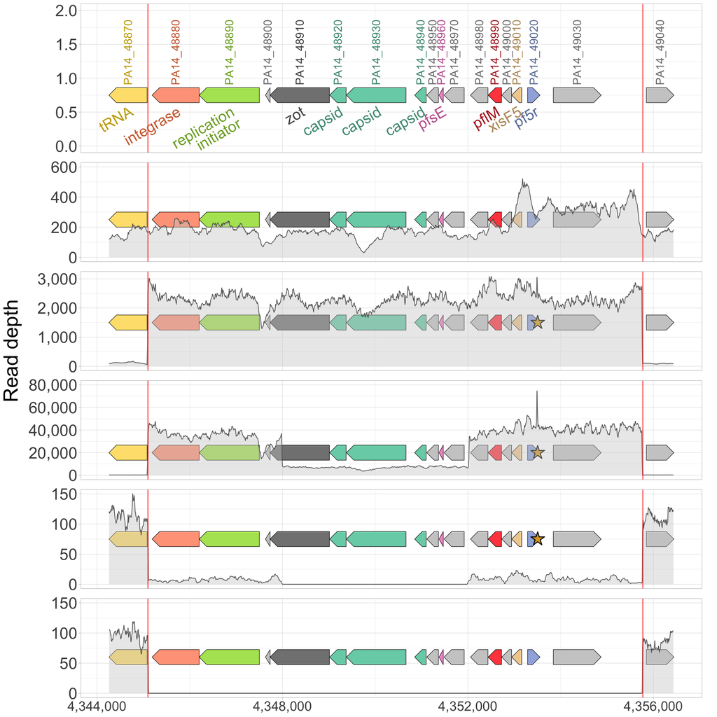

```r
pf5_annot <- pf5_6 %>% filter(id == "annot")
pf5_nonannot <- pf5_6 %>% filter(id != "annot")
rd_plot <- ggplot() +
  # geom_rect(data=pf5_nonannot, aes(xmin=new_start, xmax = new_end, ymin = 0, ymax = Inf, fill = label), alpha = 0.4) +
  # scale_fill_manual(values = lighten(pf_colors, 0.4), na.value = "grey80", guide = "none")+
  # new_scale_fill() +
  geom_gene_arrow(data=pf5_6, aes(xmin = new_start, xmax = new_end, y = r,fill = label),arrowhead_height = unit(8, "mm"),arrowhead_width = unit(4, "mm"),arrow_body_height = unit(8,"mm"))+
  facet_grid(forcats::fct_relevel(id)~., scales = "free_y")+
  facetted_pos_scales(y = r_y_lim) +
  force_panelsizes(rows = c(1.5, 1,1,1,1, 1))+
  scale_fill_manual(values = lighten(pf_colors, 0.2), name="Gene", na.value = "grey80")+
  scale_color_manual(values = darken(pf_colors, 0.2))+
  theme_light()+
  labs(y = "Read depth")+
  theme(axis.title.x = element_blank(),
        axis.title.y = element_text(size=30, margin = margin(t = 0, r = 10, b = 0, l = 0)),
        axis.text.x = element_text(size=20),
        axis.text.y = element_text(size=24),
        legend.position = "none",
        strip.background = element_blank(),
        strip.text.x = element_blank(),
        # text = element_text(size = 24),
        panel.margin.y=unit(1,"lines"))+
  scale_x_continuous(labels=comma, limits = c(4344257,4356442))+
  # geom_text(data=pf5_6, aes(x=label_position, y=rnorm, label=stringr::str_wrap(locus_flank_text,10), color=label), angle = 45, nudge_y = 0.1, nudge_x = -250, hjust = 1, size=5) +
  geom_star(data=pf5r_mut, aes(x=x, y=r), starshape=1, fill="goldenrod", size=6, starstroke=1)+
  geom_line(data=rd.sub, aes(x=start,y=read_depth), color="grey30")+
  geom_area(data=rd.sub, aes(x=start,y=read_depth), fill="grey80", position = 'identity', alpha=0.4)+
  geom_vline(xintercept = c(4345098,4355772), alpha=0.5, color = "red", linewidth=1)+
  geom_text(data=pf5_6, aes(x=label_position, y=r, label=stringr::str_wrap(label_text,10), color=label), angle = 30, nudge_x = 20, nudge_y = -0.15, hjust = 1, vjust=1, size=8, lineheight = 0.75) +
  geom_text(data=pf5_6, aes(x=label_position, y=r, label=locus_text, color=label), angle = 90, nudge_y = 0.15, nudge_x = 0, hjust = 0, vjust=0.5, size=6)
rd_plot
```

Save

```r
ggsave("./figures/Pf5_read_depth_raw_rev.svg", plot = rd_plot, device = "svg",width = unit(18,"cm"), height = unit(15,"cm"), dpi = 300)

ggsave("./figures/Pf5_read_depth_raw_rev.png", plot = rd_plot, device = "png",width = unit(18,"cm"), height = unit(15,"cm"), dpi = 300)
```

#### 2.2.1.2 normalized

Plot

```r
pf5_annot <- pf5_6 %>% filter(id == "annot")
pf5_nonannot <- pf5_6 %>% filter(id != "annot")
rnorm_plot <- ggplot() +
  geom_gene_arrow(data=pf5_6, aes(xmin = new_start, xmax = new_end, y = rnorm,fill = label),arrowhead_height = unit(8, "mm"),arrowhead_width = unit(4, "mm"),arrow_body_height = unit(8,"mm"))+
  facet_grid(forcats::fct_relevel(id)~., scales = "free_y")+
  facetted_pos_scales(y = r_norm_y_lim) +
  force_panelsizes(rows = c(1.5, 1,1,1,1, 1))+
  scale_fill_manual(values = lighten(pf_colors, 0.2), name="Gene", na.value = "grey80")+
  scale_color_manual(values = darken(pf_colors, 0.2))+
  theme_light()+
  labs(y = "Phage read depth relative to bacterial chromosome")+
  theme(axis.title.x = element_blank(),
        axis.title.y = element_text(size=30, margin = margin(t = 0, r = 10, b = 0, l = 0)),
        axis.text.x = element_text(size=20),
        axis.text.y = element_text(size=24),
        legend.position = "none",
        strip.background = element_blank(),
        strip.text.x = element_blank(),
        # text = element_text(size = 24),
        panel.margin.y=unit(1,"lines"))+
  scale_x_continuous(labels=comma, limits = c(4344257,4356442))+
  geom_star(data=pf5r_mut, aes(x=x, y=rnorm), starshape=1, fill="goldenrod", size=6, starstroke=1)+
  geom_line(data=rd.sub, aes(x=start,y=norm), color="grey30")+
  geom_area(data=rd.sub, aes(x=start,y=norm), fill="grey80", position = 'identity', alpha=0.4)+
  geom_vline(xintercept = c(4345098,4355772), alpha=0.5, color = "red", linewidth=1)+
  geom_text(data=pf5_6, aes(x=label_position, y=rnorm, label=stringr::str_wrap(label_text,10), color=label), angle = 30, nudge_x = 20, nudge_y = -0.15, hjust = 1, vjust=1, size=8, lineheight = 0.75) +
  geom_text(data=pf5_6, aes(x=label_position, y=rnorm, label=locus_text, color=label), angle = 90, nudge_y = 0.15, nudge_x = 0, hjust = 0, vjust=0.5, size=6)
```

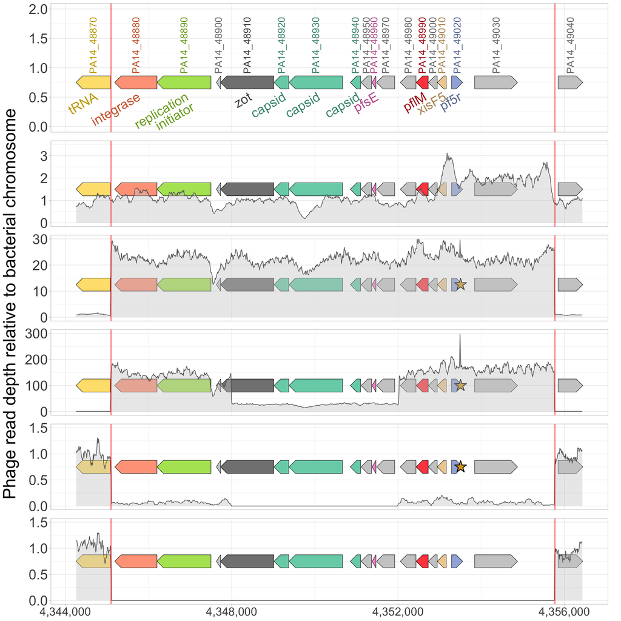

```r
rnorm_plot
```

Save

```r
ggsave("./figures/Pf5_read_depth_normalized_rev.svg", plot = rnorm_plot, device = "svg",width = unit(18,"cm"), height = unit(15,"cm"), dpi = 300)

ggsave("./figures/Pf5_read_depth_normalized_rev.png", plot = rnorm_plot, device = "png",width = unit(18,"cm"), height = unit(15,"cm"), dpi = 300)
```

#### 2.2.1.3 PA14 WT

To address reviewer comment.

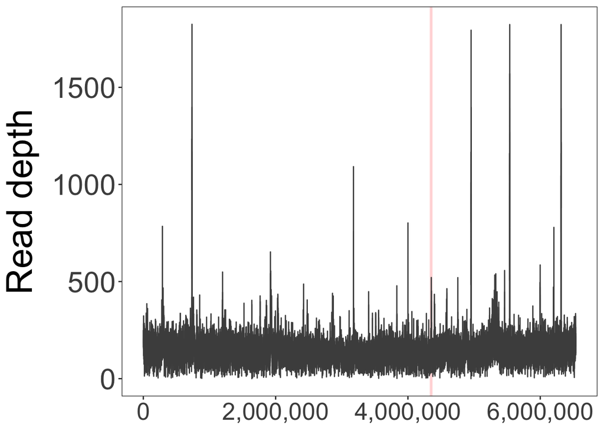

```r
wt_rd_plot <- ggplot() +
  theme_bw()+
  labs(y = "Read depth")+
  theme(axis.title.x = element_blank(),
        axis.title.y = element_text(size=30, margin = margin(t = 0, r = 10, b = 0, l = 0)),
        axis.text.x = element_text(size=20),
        axis.text.y = element_text(size=24),
        legend.position = "none",
        strip.background = element_blank(),
        strip.text.x = element_blank(),
        panel.grid = element_blank(),
        panel.margin.y=unit(1,"lines"))+
  scale_x_continuous(labels=comma)+
  geom_vline(xintercept = c(4345098,4355772), alpha=0.1, color = "red", linewidth=1)+
  geom_line(data=wt, aes(x=start,y=read_depth), color="grey30")

wt_rd_plot
```

### 2.2.2 Full vs mini read depth

highlight miniphage vs full length phage region and calculate proportion

For original P. aeruginosa PA14 (from Pseudomonas Genome Database):

- Pf5 phage region: 4345126-4355790
- pf5r duplicated region: 4353517-4353532 (16bp)
- Miniphage junction in PA14*full/mini: = 4348020, 4352056 =
- pf5r gene ORF: 4353287-4353553

For new reference genome (use this since read depth calculated using reads mapped to new reference):

Try calculating from:

```r
full_rd <- rd.sub[which(rd.sub$start >= 4348000 & rd.sub$start <= 4352020),] #subset Pf5 region present only in full-length Pf5 phage
pf5_rd <- rd.sub[which(rd.sub$start >= 4345110 & rd.sub$start <= 4355760),] #subset only Pf5 reads (removing flanking gene)
mini_full_rd <- pf5_rd[which((pf5_rd$start >= 4345110 & pf5_rd$start <= 4348000) | (pf5_rd$start >= 4352020 & pf5_rd$start <= 4355760)),] #subset full+mini region
mini_full_rd <- mini_full_rd[which(!(mini_full_rd$start >= 4353259 & mini_full_rd$start <= 4353525)),] #remove pf5r region b/c some reads don't bind due to pf5r mutation
```

Create dataframe with mean and sd of full vs full/mini normalized reads

```r
full_stat <- full_rd %>%
  group_by(id) %>%
  summarise(mean= mean(norm), sd= sd(norm), max = max(norm),min = min(norm))
full_stat$region <- "Pf5*full"
mini_full_stat <- mini_full_rd %>%
  group_by(id) %>%
  summarise(mean= mean(norm), sd= sd(norm), max = max(norm),min = min(norm))
mini_full_stat$region <- "Pf5*full + Pf5*mini"

all_stat <- rbind(full_stat, mini_full_stat) %>%
  mutate(
    mean_round = ifelse(id %in% c("wt", "f", "fm"), round(mean, digits = 2), round(mean, digits = 3))
    )
```

Relabel strains

```r
all_stat$label <- NA
all_stat[which(all_stat$id == "wt"),"label"] <- "PA14 WT"
all_stat[which(all_stat$id == "f"),"label"] <- "PA14*full"
all_stat[which(all_stat$id == "fm"),"label"] <- "PA14*full/mini"
all_stat[which(all_stat$id == "m"),"label"] <- "PA14*mini"
all_stat[which(all_stat$id == "delPf5"),"label"] <- "PA14ΔPf5"
```

Plot

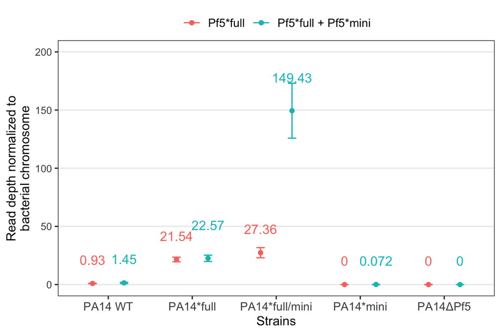

```r
all_stat_plot <- ggplot(all_stat, aes(x=label, y=mean, group=region, color=region, label=mean_round))+
  geom_point(position = position_dodge(w = 0.75))+
  geom_errorbar(aes(ymin=mean-sd, ymax=mean+sd), width=.2, position=position_dodge(w = 0.75))+
  geom_text(position=position_dodge(0.75), vjust=c(-2,-2,-2,-2,-2,-2,-3,-3,-2,-2), show.legend = FALSE, size=4)+
  labs(x="Strains", y="Read depth normalized to\nbacterial chromosome", color="Pf5 region")+
  scale_y_continuous(limits = c(0,200), breaks = seq(0,200,50))+
  theme_bw()+
  theme(
    panel.grid.major.x = element_blank(),
    panel.grid.minor.x = element_blank(),
    panel.grid.minor.y = element_blank(),
    legend.position = "top",
    legend.text = element_text(size=10),
    legend.title = element_blank(),
    legend.box.margin=margin(0,0,1,0),
    legend.box.spacing = unit(0, "pt"),
    axis.text.x  = element_text(size=10)
    )
all_stat_plot
```

Save graph

```r
ggsave("./figures/full_mini_read_depth_normalized_stat_rev.png", plot = all_stat_plot, width = unit(6,"cm"), height = unit(3,"cm"), dpi = 300)

ggsave("./figures/full_mini_read_depth_normalized_stat_rev.svg", plot = all_stat_plot, width = unit(6,"cm"), height = unit(3,"cm"), dpi = 300)
```

### 2.2.3 Miniphage diversity

```r
mini_del <- read.csv("./whole_genome_sequencing/breseq_data/breseq_miniphage.csv")
strain_order <- c("PA14", "PA14*mini", "PA14*full/mini 4", "PA14*full/mini 3", "PA14*full/mini 2", "PA14*full/mini 1")

mini_del_long <- mini_del %>%
  mutate(
    ylabel = factor(strain, levels = strain_order),
    line_num = row_number(),
    text_color = ifelse(side_1_position==4348001, "red", "black")
    )

mini_color <- mini_del_long %>%
  select(color, ylabel) %>%
  mutate(ylabel = factor(ylabel, levels = strain_order)) %>%
  arrange(ylabel)

pf5_single <- pf5 %>%
  mutate(ylabel = "PA14") %>%
  mutate(ylabel = factor(ylabel, levels = strain_order))

mini_div_plot <- ggplot()+
  geom_vline(xintercept = c(4345098,4355762), alpha=0.5, color = "red")+
  geom_gene_arrow(data=pf5_single, aes(xmin = new_start, xmax = new_end, y = ylabel, fill = label),arrowhead_height = unit(0.75, "cm"),arrowhead_width = unit(3, "mm"),arrow_body_height = unit(0.75,"cm"))+
  scale_fill_manual(values = lighten(pf_colors, 0.2), name="Gene", na.value = "white")+
  scale_color_manual(values = darken(pf_colors, 0.2))+
  theme_light() +
  scale_x_continuous(labels=comma)+
  geom_text(data=pf5_single, aes(x=label_position, y=ylabel, label=stringr::str_wrap(label,10), color=label), angle = 45, nudge_y = -0.3, hjust = 1, vjust= 1, size=4)+
  geom_linerange(data=mini_del_long, aes(y=ylabel, xmin=side_1_position, xmax=side_2_position), position = position_dodge2(width=1, preserve = "single"), color=(mini_color$color))+
  geom_text(data=mini_del_long, aes(y=ylabel, x=side_1_position, label = comma(side_1_position)),position = position_dodge2(width=1, preserve = "single"), hjust=1.1, size=2.8)+
  geom_text(data=mini_del_long, aes(y=ylabel, x=side_2_position, label = comma(side_2_position)),position = position_dodge2(width=1, preserve = "single"), hjust=-0.1, size=2.8)+
  scale_y_discrete(
    breaks = levels(mini_del_long$ylabel),
    expand = expansion(mult = 0.05),
    limits = c(
      "skip",
      levels(mini_del_long$ylabel)[1], #PA14
      levels(mini_del_long$ylabel)[-1]
      ))+
  theme(
    axis.title.x = element_blank(),
    axis.title.y = element_blank(),
    legend.position = "none",
    strip.background = element_blank(),
    strip.text.x = element_blank(),
    text = element_text(size = 15))
```

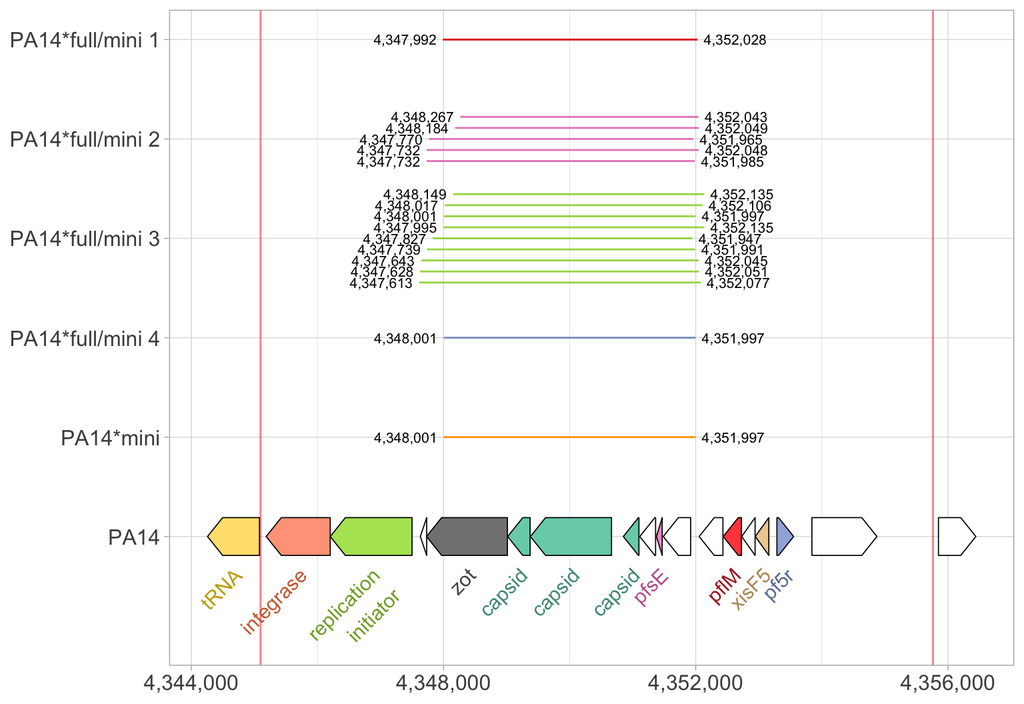

```r
mini_div_plot
```

Save

```r
ggsave("./figures/miniphage_deletion_position.png", plot = mini_div_plot, device = "png",width = unit(8,"cm"), height = unit(6,"cm"))

ggsave("./figures/miniphage_deletion_position.svg", plot = mini_div_plot, device = "svg",width = unit(8,"cm"), height = unit(6,"cm"))
```

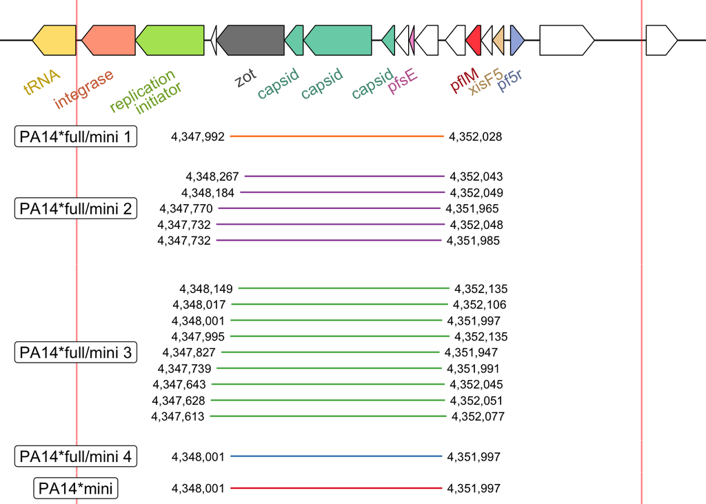

```r
facet_order <- c("PA14*full/mini 1", "PA14*full/mini 2", "PA14*full/mini 3",  "PA14*full/mini 4", "PA14*mini")
facet_label <- data.frame(
  ylabel = factor(facet_order, levels = c("PA14", "PA14*full/mini 1", "PA14*full/mini 2", "PA14*full/mini 3",  "PA14*full/mini 4","PA14*mini")),
label_position = rep(4345081, times=5),
line_num = c(2, 6, 13, 3, 1)
)

mini_div_plot2 <- ggplot() +
  geom_hline(yintercept ="PA14", color= "black")+
  geom_vline(xintercept = c(4345098,4355762), alpha=0.5, color = "red")+
  geom_gene_arrow(data=pf5_single, aes(xmin = new_start, xmax = new_end, y = ylabel, fill = label),arrowhead_height = unit(0.75, "cm"),arrowhead_width = unit(3, "mm"),arrow_body_height = unit(0.75,"cm"))+
  geom_text(data=pf5_single, aes(x=label_position, y=ylabel, label=stringr::str_wrap(label,10), color=label), angle = 30, nudge_x = 20, nudge_y = -0.5, hjust = 1, vjust=1, size=4, lineheight = 0.75)+
  scale_fill_manual(values = lighten(pf_colors, 0.2), name="Gene", na.value = "white")+
  scale_color_manual(values = darken(pf_colors, 0.2))+
  new_scale_color() +
  geom_linerange(data=mini_del_long, aes(y=line_num, xmin=side_1_position, xmax=side_2_position, color=ylabel))+
  geom_label(data=facet_label, aes(x=label_position, y=line_num, label=ylabel), angle = 0, hjust = "middle", size=4, show.legend = FALSE, lineheight=1, fill="white") +
  scale_color_manual(values = brewer_pal(palette = "Set1")(8)[-6], guide="none")+
  new_scale_color() +
  geom_text(data=mini_del_long, aes(y=line_num, x=side_1_position, label = comma(side_1_position)), hjust=1.1, size=3)+
  geom_text(data=mini_del_long, aes(y=line_num, x=side_2_position, label = comma(side_2_position)), hjust=-0.1, size=3)+
  # geom_text(data=mini_del_long, aes(y=line_num, x=side_1_position, label = comma(side_1_position), color=text_color), hjust=1.1, size=3)+
  # geom_text(data=mini_del_long, aes(y=line_num, x=side_2_position, label = comma(side_2_position), color=text_color), hjust=-0.1, size=3)+
  # scale_color_manual(values = c("black","red"), guide="none")+
  facet_grid(forcats::fct_relevel(ylabel, "PA14", "PA14*full/mini 1", "PA14*full/mini 2", "PA14*full/mini 3",  "PA14*full/mini 4", "PA14*mini")~., scales = "free_y", space = "free", drop = TRUE, switch = "y")+
  scale_y_discrete(expand = c(0, 1.5))+
  force_panelsizes(rows = c(1, 0.2, 0.7, 1.1, 0.2, 0.2)) +
  theme_light() +
  theme(
    legend.position = "none",
    axis.title.x = element_blank(),
    axis.title.y = element_blank(),
    strip.background = element_blank(),
    strip.text = element_blank(),
    # strip.text.y.left = element_text(angle = 0, color = "black", size=10, hjust=1),
    axis.text.x = element_blank(),
    axis.text.y = element_blank(),
    axis.ticks.x = element_blank(),
    axis.ticks.y = element_blank(),
    # text = element_text(size = 15),
    panel.grid.major = element_blank(),
    panel.grid.minor = element_blank(),
    panel.spacing = unit(0, "lines"),
    panel.border = element_blank(),
    plot.margin = unit(c(-1, -0.1, -0.1, -0.1), "cm"),
    strip.clip = "off"
  )
mini_div_plot2
```

Save

```r
ggsave("./figures/miniphage_deletion_position_rev.png", plot = mini_div_plot2, width = unit(8,"cm"), height = unit(6,"cm"))

ggsave("./figures/miniphage_deletion_position_rev.svg", plot = mini_div_plot2, width = unit(8,"cm"), height = unit(6,"cm"))

ggsave("./figures/miniphage_deletion_position_rev.pdf", plot = mini_div_plot2,width = unit(8,"cm"), height = unit(6,"cm"))
```

### 2.2.4 Evolved population read depth

```r
r=170

#remove locus_tag from all but last one
pf5_pop5$locus_text <- pf5_pop5$Locus.Tag
pf5_pop5[which(pf5_pop5$id != "delPf5"),"locus_text"] <- NA

pop5.plot <- ggplot() +
  geom_gene_arrow(data=pf5_pop5, aes(xmin = new_start, xmax = new_end, y = r,fill = label),arrowhead_height = unit(0.75, "cm"),arrowhead_width = unit(3, "mm"),arrow_body_height = unit(0.75,"cm"))+
  facet_wrap(~forcats::fct_relevel(id), scales = "free_y", ncol = 1)+
  scale_fill_manual(values = lighten(pf_colors_pop5, 0.2), name="Gene", na.value = "white")+
  scale_color_manual(values = darken(pf_colors_pop5, 0.2))+
  labs(y="Phage read depth relative to\nbacterial chromosome") +
  scale_x_continuous(labels=comma)+
  coord_cartesian(ylim=c(0, 250))+
  geom_text(data=pf5_pop5, aes(x=label_position, y=0.95*r, label=stringr::str_wrap(label,10), color=label), angle = 45, nudge_y = 0, hjust = 1, vjust=1, size=7) + #y=4700 for PAO1PfDI; y=160 for PAO1_WT; size=4 or 2.5, str_wrap 50, angle 50
  geom_text(data=pf5_pop5, aes(x=label_position, y=1.1*r, label=stringr::str_wrap(locus_text,10), color=label), angle = 90, nudge_y = 0, nudge_x = 0, hjust = 0, size=5) +
  geom_line(data=pop5.sub, aes(x=start,y=norm), alpha=0.4)+
  geom_area(data=pop5.sub, aes(x=start,y=norm),alpha = 0.1, position = 'identity')+
  geom_vline(xintercept = c(4345098,4355762), alpha=0.5, color = "red")+
  theme_light()+
  theme(
    axis.title.x = element_blank(),
    # axis.title.y = element_blank(),
    legend.position = "none",
    strip.background = element_blank(),
    strip.text.x = element_blank(),
    strip.text.y = element_text(size = 24),
    axis.text.x = element_text(size = 20),
    axis.text.y = element_text(size = 24),
    axis.title.y = element_text(size = 24),
    text = element_text(size = 18)
    )
```

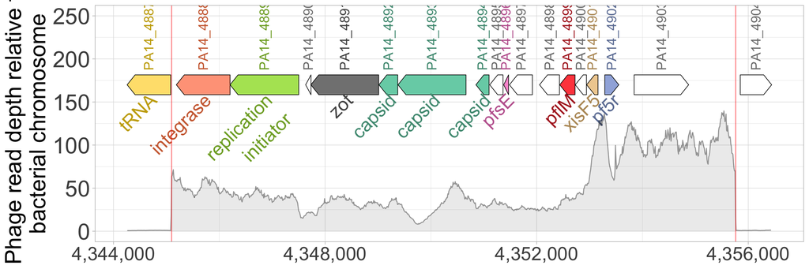

```r
pop5.plot
```

```r
ggsave("./figures/pop5_read_depth_rev.png", plot = pop5.plot, device = "png",width = unit(16,"cm"), height = unit(5,"cm"), dpi = 300)

ggsave("./figures/pop5_read_depth_rev.svg", plot = pop5.plot, device = "svg",width = unit(16,"cm"), height = unit(5,"cm"), dpi = 300)
```

population raw reads

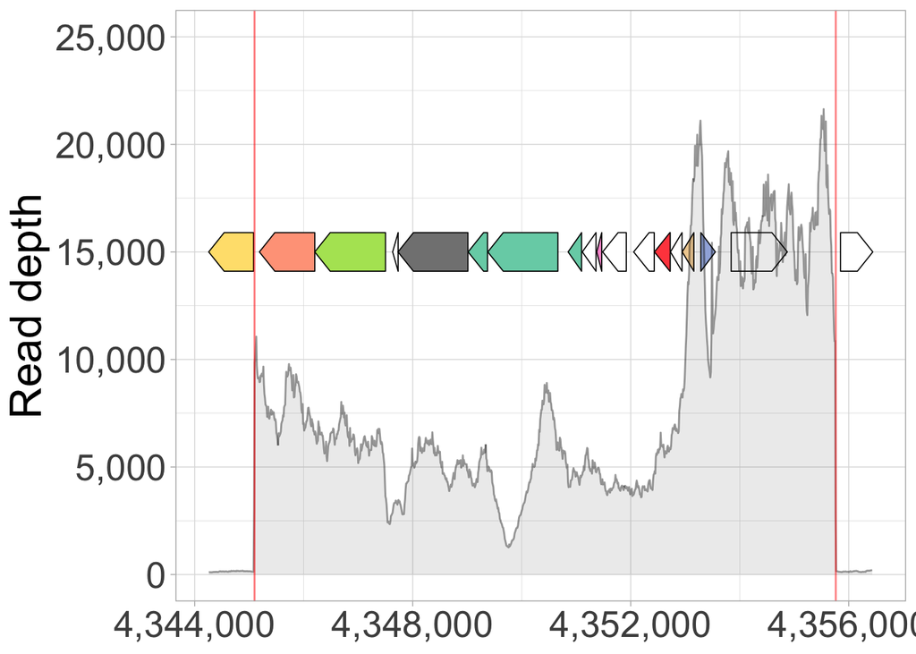

```r
r=15000
pop5_raw_plot <- ggplot() +
  geom_gene_arrow(data=pf5_pop5, aes(xmin = new_start, xmax = new_end, y = r,fill = label),arrowhead_height = unit(0.75, "cm"),arrowhead_width = unit(3, "mm"),arrow_body_height = unit(0.75,"cm"))+
  facet_wrap(~forcats::fct_relevel(id), scales = "free_y", ncol = 1)+
  scale_fill_manual(values = lighten(pf_colors_pop5, 0.2), name="Gene", na.value = "white")+
  scale_color_manual(values = darken(pf_colors_pop5, 0.2))+
  labs(y="Read depth") +
  scale_x_continuous(labels=comma, limits = c(4344257,4356442))+
  scale_y_continuous(labels=comma, limits = c(0, 25000))+
  # coord_cartesian(ylim=c(0, 25000))+
  # geom_text(data=pf5_pop5, aes(x=label_position, y=0.95*r, label=stringr::str_wrap(label,10), color=label), angle = 45, nudge_y = 0, hjust = 1, vjust=1, size=7) +
  # geom_text(data=pf5_pop5, aes(x=label_position, y=1.1*r, label=stringr::str_wrap(locus_text,10), color=label), angle = 90, nudge_y = 0, nudge_x = 0, hjust = 0, size=5) +
  geom_line(data=pop5.sub, aes(x=start,y=read_depth), alpha=0.4)+
  geom_area(data=pop5.sub, aes(x=start,y=read_depth),alpha = 0.1, position = 'identity')+
  geom_vline(xintercept = c(4345098,4355762), alpha=0.5, color = "red")+
  theme_light()+
  theme(
    axis.title.x = element_blank(),
    # axis.title.y = element_blank(),
    legend.position = "none",
    strip.background = element_blank(),
    strip.text.x = element_blank(),
    strip.text.y = element_text(size = 24),
    axis.text.x = element_text(size = 20),
    axis.text.y = element_text(size = 20),
    axis.title.y = element_text(size = 24),
    text = element_text(size = 18)
    )
pop5_raw_plot
```

```r
ggsave("./figures/pop5_read_depth_raw_rev.png", plot = pop5_raw_plot, device = "png",width = unit(16,"cm"), height = unit(5,"cm"), dpi = 300)

ggsave("./figures/pop5_read_depth_raw_rev.svg", plot = pop5_raw_plot, device = "svg",width = unit(16,"cm"), height = unit(5,"cm"), dpi = 300)
```

# 3 Growth curve OD600

## 3.1 Prepare data

```r
file <- "./growth_curves/OD600/Plate_reader_2024-06-30.csv"
p <- read.csv(file,header=T,skip = 2)

p <- head(p,-5) #remove last few rows
p <- p[,-2] #remove temperature column

p[97,which(colnames(p)%in%"Time")]  <- c("24:00:00") #run for newer program

k <- "./growth_curves/OD600/Plate_key_2024-06-29.csv"
key <- read.csv(k,header=F) #key to denote what samples are in each well

for (i in 2:ncol(p)) {
  well <- colnames(p)[i]
  num <- which(key[,1]%in%well)
  colnames(p)[i] <- as.character(key[num,2])
}

blank <- p[,which(colnames(p)%in%"blank")]
indx <- sapply(blank, is.character)
blank[indx] <- lapply(blank[indx], function(x) as.numeric(x))
blank_mean <- data.frame(Time=p[,1],Means=rowMeans(blank,na.rm=TRUE))
pdata <- p[,-which(colnames(p)%in%"blank")]
pdata$blank_mean <- blank_mean[,2] #name new column blank_mean with average of all blanks
pcal <- pdata
for (i in 2:ncol(pdata)) {
  pcal[,i] <- as.numeric(as.character(pdata[,i]))-as.numeric(as.character(pdata$blank_mean))
}
pclean <- pcal[,-which(colnames(pcal)%in%"blank_mean")]
pclean$Time <- p[,1]

pclean$Time <- as.factor(pclean$Time)
pclean$Time_convert <- unlist(lapply(lapply(strsplit(as.character(pclean$Time), ":"), as.numeric), function(x) x[1]+x[2]/60))
pclean2 <- pclean[,!names(pclean) %in% c("Time")]
pclean2 <- pclean2[,!names(pclean2) %in% c("Time(hh:mm:ss)")] #only for older program?
pmelt <- melt(pclean2,id.vars="Time_convert") #melt dataframe
pmelt$strain <- gsub("\\..*","",pmelt$variable) #remove period and numbers from strain names
pmelt <- pmelt[!(is.na(pmelt$strain) | (pmelt$strain == 'NA')),] #remove NAs

data_summary <- function(data, varname, groupnames){
  summary_func <- function(x, col){
    c(mean = mean(x[[col]], na.rm=TRUE),
      sd = sd(x[[col]], na.rm=TRUE))
  }
  data_sum<-plyr::ddply(data, groupnames, .fun=summary_func,
                  varname)
  data_sum <- plyr::rename(data_sum, c("mean" = varname))
  return(data_sum)
}

pilA_gc <- data_summary(pmelt,varname = "value",groupnames = c("strain","Time_convert"))

pilA_gc$label = factor(pilA_gc$strain, levels=c("Lac Ancestor", "PA14 pilA","B1", "new G1"))
exprvec <- c("PA14 WT", expression(paste("PA14",Delta,italic("pilA"))), "PA14*full", "PA14*full/mini")
```

## 3.2 growth curver

GC stats

```r
#Compare area under the curve--load data
#Remove blank row and keep only the columns sample, k, r, auc_e
gc_out3 <- read.csv("./growth_curves/OD600/growth_curve_calc.csv") %>%
  select(sample,k,auc_e) %>%
  subset(sample == "Lac Ancestor" | sample == "PA14 pilA" | sample == "new G1" | sample == "B1")

#Clean the names for downstream labeling of the dot plot
names(gc_out3)[names(gc_out3) == 'sample'] <- 'Strains'
gc_long <- melt(gc_out3, id = "Strains")
levels(gc_long$variable) <- c("Carrying~Capacity~(Final~OD[600])", "Area~Under~the~Curve~(AUC)")

gc_long$label = factor(gc_long$Strains, levels=c("Lac Ancestor", "PA14 pilA","B1", "new G1"))
```

## 3.3 Figure

### 3.3.1 Timepoints

```r
pilA_gc_plot <- ggplot(pilA_gc, aes(x=Time_convert, y=value, group=strain, color=label)) +
  geom_errorbar(aes(ymin=value-sd, ymax=value+sd), width=.1,position=position_dodge(0.05)) +
  geom_line() +
  scale_y_continuous(trans = 'log10')+ #use for log scale
  scale_color_manual(values = col_hex, drop=F, labels=exprvec)+
  labs(color = "Strains", x="Time (h)", y=expression(OD[600]))+
  theme_bw()+
  guides(colour = guide_legend(override.aes = list(linewidth = 3)))+
  theme(
    legend.position = "top",
    # text = element_text(size = 16),
    legend.title = element_blank(),
    legend.text = element_text(size = 18),
    axis.text = element_text(size=18),
    axis.title = element_text(size=20))
```

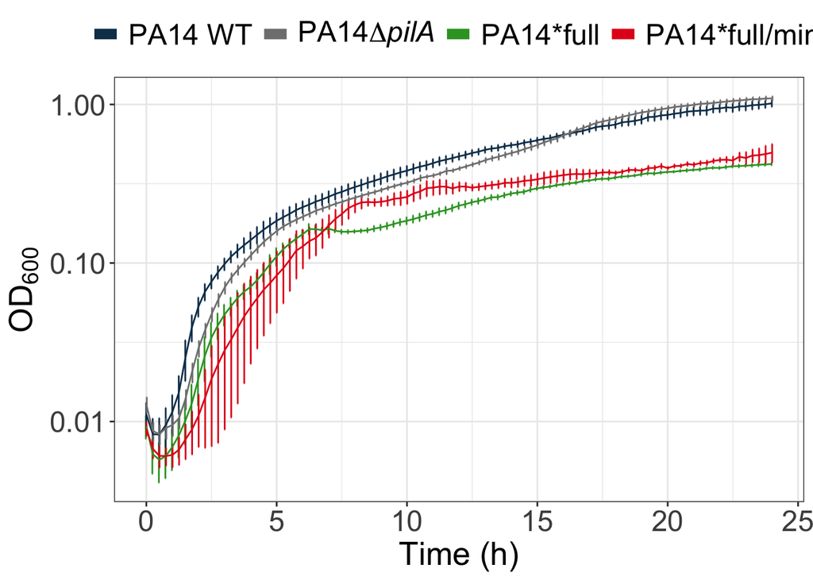

```r
pilA_gc_plot
```

```r
ggsave("./figures/growth_curve_OD600_rev.png", plot = pilA_gc_plot, device = "png",width = unit(8,"cm"), height = unit(5,"cm"))
ggsave("./figures/growth_curve_OD600_rev.svg", plot = pilA_gc_plot, device = "svg",width = unit(8,"cm"), height = unit(5,"cm"))
```

### 3.3.2 Growth curve stats

```r
#create dummy data to set individual y-axis limits for facet_wrap
od600_range <- c(0, 1.5) #range(gc_long[which(gc_long$variable == "Carrying~Capacity~(Final~OD[600])"), "value"])
auc_range <- c(0,16) #range(gc_long[which(gc_long$variable == "Area~Under~the~Curve~(AUC)"), "value"])
dummy <- data.frame(label = rep("PA14 pilA",4), value = c(od600_range, auc_range), variable = rep(unique(gc_long$variable), each=2), stringsAsFactors=FALSE)
```

Stats

```r
auc_stat <- gc_long %>%
  filter(variable == "Area~Under~the~Curve~(AUC)")

kruskal.test(value ~ label, data = auc_stat)
```

```
##
##  Kruskal-Wallis rank sum test
##
## data:  value by label
## Kruskal-Wallis chi-squared = 29.639, df = 3, p-value = 1.644e-06
```

```r
#can't do anova since levene's test shows that variance is unequal
# anova_result <- aov(value ~ label, data = auc_stat)
# summary(anova_result)
# TukeyHSD(anova_result)
# levene_test(value ~ label, data = auc_stat)
```

```r
auc_dunn <- auc_stat %>%
  dunn_test(value ~ label) %>%
  add_xy_position(x = "label") %>%
  mutate(variable = "Area~Under~the~Curve~(AUC)")
```

```r
cp_stat <- gc_long %>%
  filter(variable == "Carrying~Capacity~(Final~OD[600])")

kruskal.test(value ~ label, data = cp_stat)
```

```
##
##  Kruskal-Wallis rank sum test
##
## data:  value by label
## Kruskal-Wallis chi-squared = 29.735, df = 3, p-value = 1.569e-06
```

```r
cp_dunn <- cp_stat %>%
  dunn_test(value ~ label) %>%
  add_xy_position(x = "label") %>%
  mutate(variable = "Carrying~Capacity~(Final~OD[600])")
```

combine stat dataframe

```r
stat_dunn <- rbind(auc_dunn, cp_dunn) %>%
  mutate(
    #adjust height (y position) of significance bracket to make it less cluttered
    y.position = case_when(
      (group1 == "B1" & group2=="new G1" & variable == "Carrying~Capacity~(Final~OD[600])") ~ 0.75,
      (group1 == "PA14 pilA" & group2=="B1" & variable == "Carrying~Capacity~(Final~OD[600])") ~ 0.85,
      (group1 == "PA14 pilA" & group2=="B1" & variable == "Area~Under~the~Curve~(AUC)") ~ 8.5,
      (group1 == "B1" & group2=="new G1" & variable == "Area~Under~the~Curve~(AUC)") ~ 7.5,
      (group1 == "PA14 pilA" & group2=="new G1" & variable == "Carrying~Capacity~(Final~OD[600])") ~ 1,
      (group1 == "PA14 pilA" & group2=="new G1" & variable == "Area~Under~the~Curve~(AUC)") ~ 9.5,
      TRUE ~ y.position
    )
  )
```

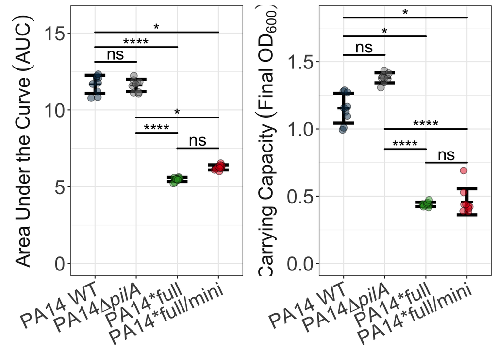

```r
#Dot plot of carrying capacity, growth rate, area under the curve (auc_e)
gc_stat2 <- ggplot(gc_long, aes(x = label, y = value,fill=label,color=label)) +
  scale_x_discrete(labels=exprvec)+
  facet_wrap(~variable, scales = "free",strip.position = "left",labeller = label_parsed)+
  geom_blank(data=dummy)+ #dummy data to set y axis limits
  scale_fill_manual(values = col_hex, drop=F, labels=exprvec)+
  scale_color_manual(values = col_hex, drop=F, labels=exprvec)+
  stat_summary(fun.min=function(y)(mean(y)-sd(y)),
               fun.max=function(y)(mean(y)+sd(y)),
               geom="errorbar", width=0.5, color="black", linewidth=1.5) +
  stat_summary(fun=base::mean, geom="crossbar", fatten=2, width=0.3, color="black")+
  geom_point(size=3, alpha=0.5, shape=21, color="black", position=position_jitter(w=0.1, h=0))+
  stat_pvalue_manual(
    stat_dunn,
    tip.length = 0,
    bracket.size=0.8,
    size=6,
    show.legend = FALSE
    )+
  theme_bw()+
  theme(
    axis.title.y = element_blank(),
    axis.title.x = element_blank(),
    axis.text.x = element_text(angle = 25, vjust = 1, hjust=1,size=20),
    axis.text.y = element_text(size=20),
    strip.background = element_blank(),
    strip.placement = "outside",
    legend.position = "none",
    text = element_text(size = 18),
    strip.text = element_text(size=20)
    )
gc_stat2
```

```r
ggsave("./figures/growth_curve_OD600_stats_rev.png", plot = gc_stat2, device = "png",width = unit(8,"cm"), height = unit(6,"cm"))

ggsave("./figures/growth_curve_OD600_stats_rev.svg", plot = gc_stat2, device = "svg",width = unit(8,"cm"), height = unit(6,"cm"))
```

# 4 Growth Curve CFU/mL

## 4.1 WT data

Read data

```r
cfu <- read.csv("./growth_curves/cfu_ml/growth_cfu.csv")
cfu$id <- paste(cfu$abbreviation, cfu$bio_rep)
```

Rename strain to appropriate names

```r
cfu$bac_label <- NA
cfu[which(cfu$bacteria == "Ancestor"), "bac_label"] <- "PA14 WT"
cfu[which(cfu$bacteria == "B1"), "bac_label"] <- "PA14*full"
cfu[which(cfu$bacteria == "new G1"), "bac_label"] <- "PA14*full/mini"

cfu$sup_label <- "None"
cfu[which(cfu$supernatant == "Ancestor"), "sup_label"] <- "PA14 WT"
cfu[which(cfu$supernatant == "B1"), "sup_label"] <- "PA14*full"
cfu[which(cfu$supernatant == "new G1"), "sup_label"] <- "PA14*full/mini"
```

## 4.2 pilA data

```r
cfu_pilA <- read.csv("./growth_curves/cfu_ml/pilA_growth_cfu.csv")
cfu_pilA$id <- paste(cfu_pilA$abbreviation, cfu_pilA$bio_rep)

cfu_pilA$bac_label <- "PA14 pilA"
#rename names to appropriate labels
cfu_pilA$sup_label <- "None"
cfu_pilA[which(cfu_pilA$supernatant == "Ancestor"), "sup_label"] <- "PA14 WT"
cfu_pilA[which(cfu_pilA$supernatant == "pilA"), "sup_label"] <- "PA14 pilA"

cfu_pilA$sup_color <- cfu_pilA$sup_label

cfu_pilA[which(cfu_pilA$supernatant == "B1"), "sup_label"] <- "PA14*full"
cfu_pilA[which(cfu_pilA$supernatant == "new G1"), "sup_label"] <- "PA14*full/mini"

cfu_pilA[which(cfu_pilA$supernatant == "B1"), "sup_color"] <- "B1"
cfu_pilA[which(cfu_pilA$supernatant == "new G1"), "sup_color"] <- "new G1"
cfu_pilA$sup_color = factor(cfu_pilA$sup_color, levels=c("None", "PA14 WT", "PA14 pilA","B1", "new G1"))
cfu_pilA$sup_label = factor(cfu_pilA$sup_label, levels=c("None", "PA14 WT", "PA14 pilA","PA14*full", "PA14*full/mini"))

exprvec <- c("None", "PA14 WT", expression(paste("PA14",Delta,italic("pilA"))), "PA14*full", "PA14*full/mini")
```

## 4.3 Figures

### 4.3.1 pilA supernatant treatment

```r
anc <- cfu %>%
  filter(bacteria == "Ancestor")

anc$sup_color <- anc$sup_label
anc[which(anc$supernatant == "B1"), "sup_color"] <- "B1"
anc[which(anc$supernatant == "new G1"), "sup_color"] <- "new G1"
cfu_pilA_anc <- rbind(anc, cfu_pilA)

cfu_pilA_anc$sup_color = factor(cfu_pilA_anc$sup_color, levels=c("None", "PA14 WT", "PA14 pilA", "B1", "new G1"))
exprvec <- c("None", "PA14 WT", expression(paste("PA14",Delta,italic("pilA"))), "PA14*full", "PA14*full/mini")

cfu_pilA_anc$sup_label <- factor(cfu_pilA_anc$sup_label,levels = c("None", "PA14 WT", "PA14 pilA", "PA14*full", "PA14*full/mini"))

cfu_pilA_anc$bac_label <- factor(cfu_pilA_anc$bac_label,levels = c("PA14 WT", "PA14 pilA"), ordered = T, labels= c("<b>PA14 WT</b>", "<b>PA14&Delta;<i>pilA</i></b>"))
```

take average of replicates

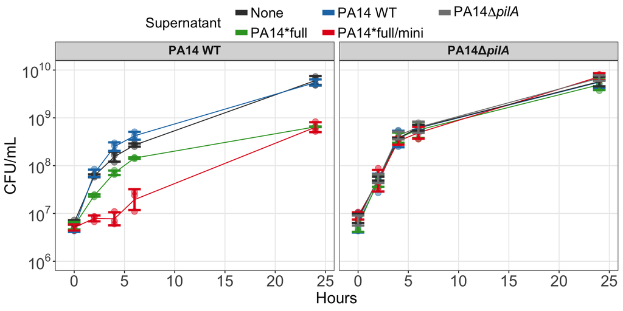

```r
pilA_anc_sup_avg_plot <- ggplot(cfu_pilA_anc, aes(x=hour, y=CFU.mL, group=abbreviation, color=sup_label))+
  geom_point(alpha=0.5, size=3, shape=19, show.legend = FALSE)+
  # geom_line()+
  facet_wrap(~bac_label, ncol = 2)+
  # scale_y_continuous(trans = "log10", breaks = c(1e6,1e7,1e8,1e9,1e10), limits = c(1e6,1e10))+
  scale_y_log10(breaks = trans_breaks("log10", function(x) 10^x),labels = trans_format("log10", math_format(10^.x)), limits = c(1e6,1e10))+
  scale_color_manual(values = col_hex2, labels=exprvec)+
  stat_summary(fun=mean, geom = "line")+
  stat_summary(fun.min=function(y)(mean(y)-sd(y)),
               fun.max=function(y)(mean(y)+sd(y)),
               geom="errorbar", width=1.25, size=1.25) +
  labs(x="Hours", y="CFU/mL", color="Supernatant")+
  theme_bw()+
  guides(colour = guide_legend(override.aes = list(linewidth = 3), nrow=2, byrow=TRUE))+
  theme(
    axis.title.y = element_text(size=18),
    axis.title.x = element_text(size=18),
    axis.text = element_text(size=18),
    # text = element_text(size = 18),
    strip.text = element_markdown(size=14),
    legend.text = element_text(hjust=0, size=16, margin = margin(r = 10, l=2, unit = "pt")),
    legend.position = "top",
    legend.title = element_text(size=16, margin = margin(r = 15)),
    legend.margin=margin(0,0,1,0),
    legend.box.margin=margin(0,0,1,0),
    legend.box.spacing = unit(0, "pt"),
    legend.spacing.x = unit(1.5, "cm"),
    panel.grid.minor = element_blank()
  )
pilA_anc_sup_avg_plot
```

save

```r
ggsave(plot = pilA_anc_sup_avg_plot, filename = "./figures/supernatant_CFU_mL_rev.png", units = "cm", width = 20, height = 12, dpi = 300)

ggsave(plot = pilA_anc_sup_avg_plot, filename = "./figures/supernatant_CFU_mL_rev.svg", units = "cm", width = 20, height = 12, dpi = 300)
```

### 4.3.2 Bacteria growth curve

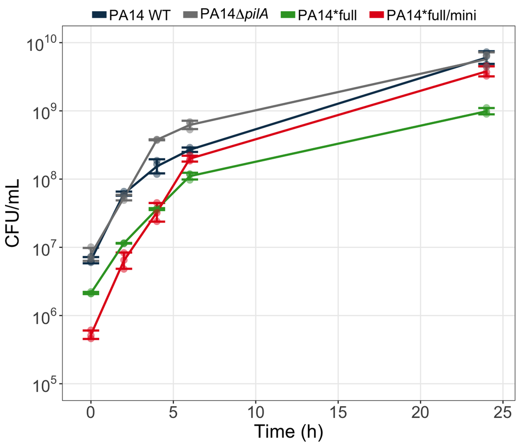

```r
sub2 <- cfu %>%
  filter(abbreviation %in% c("A", "B", "G"))

cfu_pilA_ns <- cfu_pilA %>%
  filter(is.na(supernatant)) %>%
  select(-sup_color)

sub2_pilA <- rbind(sub2, cfu_pilA_ns)
sub2_pilA$bac_color <- sub2_pilA$bac_label

sub2_pilA$bac_label <- factor(sub2_pilA$bac_color,levels = c("PA14 WT", "PA14 pilA", "PA14*full", "PA14*full/mini"), ordered = T)

exprvec <- c(expression(paste("PA14 ","WT")), expression(paste("PA14",Delta,italic("pilA"))),expression(paste("PA14*full")),expression(paste("PA14*full/mini")))

col_hex3 <- col_hex
names(col_hex3)[4] <- "PA14 WT"

plot_sub3 <- ggplot(sub2_pilA, aes(x=hour, y=CFU.mL, group=bac_label, color=bac_label))+
  stat_summary(fun.min=function(y)(mean(y)-sd(y)),
               fun.max=function(y)(mean(y)+sd(y)),
               geom="errorbar", width=1, linewidth=1) +
  stat_summary(fun=mean, geom = "line", linewidth=1)+
  scale_y_log10(breaks = c(1e5, 1e6, 1e7, 1e8, 1e9, 1e10),labels = trans_format("log10", math_format(10^.x)), limits = c(1e5, 1e10)) +
  geom_point(alpha=0.5, size=3, shape=16, show.legend = FALSE)+
  scale_color_manual(values = col_hex3, labels=exprvec)+

  labs(x="Time (h)", y="CFU/mL")+
  guides(colour = guide_legend(override.aes = list(linewidth = 3)))+
  theme_bw()+
  theme(
    legend.position = "top",
    legend.title = element_blank(),
    legend.text = element_text(size=14, margin = margin(r = 10, l=1, unit = "pt")),
    legend.margin=margin(0,0,1,0),
    legend.box.margin=margin(0,0,1,0),
    legend.box.spacing = unit(0, "pt"),
    legend.key.spacing.x = unit(0, "pt"),
    text = element_text(size = 18),
    axis.title = element_text(size=18),
    axis.text = element_text(size=16),
    panel.grid.minor = element_blank()
    )
plot_sub3
```

```r
ggsave(plot = plot_sub3, filename = "./figures/growth_curve_CFU_mL_rev.png", width = unit(6,"cm"), height = unit(4.5,"cm"), dpi = 300)

ggsave(plot = plot_sub3, filename = "./figures/growth_curve_CFU_mL_rev.svg", width = unit(6,"cm"), height = unit(4.5,"cm"), dpi = 300)
```

### 4.3.3 CFU stats

with pilA at 24h

```r
sub2_pilA_24h <- sub2_pilA %>%
  filter(hour == 24)
```

calculate significance using kruskal wallis

```r
kruskal.test(CFU.mL ~ bac_label, data = sub2_pilA_24h)
```

```
##
##  Kruskal-Wallis rank sum test
##
## data:  CFU.mL by bac_label
## Kruskal-Wallis chi-squared = 8.7436, df = 3, p-value = 0.0329
```

```r
cfu_dunn <- sub2_pilA_24h %>%
  dunn_test(CFU.mL ~ bac_label) %>%
  add_xy_position(x = "bac_label")
```

```r
cfu_stat_plot2 <- ggplot(sub2_pilA_24h, aes(x=bac_label, y=CFU.mL, color=bac_label, fill=bac_label, group=bac_label))+
  stat_summary(fun.min=function(y)(mean(y)-sd(y)),
               fun.max=function(y)(mean(y)+sd(y)),
               geom="errorbar", width=0.3, size=1.5, color="black") +
  stat_summary(fun=base::mean, geom="crossbar", fatten = 3, width = 0.2)+
  labs(y="CFU/mL at 24 hours")+
  geom_point(size=3, alpha=0.75, position=position_jitter(w=0.1, h=0))+
  scale_color_manual(values = col_hex3)+
  scale_x_discrete(labels=exprvec)+
  # scale_y_continuous(limits = c(1e8,9e9), breaks = c(1e8,5e8,1e9,5e9,9e9))+
  scale_y_log10(breaks = c(1e8,1e9,1e10), labels = trans_format("log10", math_format(10^.x)), limits = c(1e8,9e9)) +
  theme_bw()+
  theme(axis.title.x = element_blank(),
        legend.position = "none",
        text = element_text(size = 18),
        axis.text.x = element_text(angle = 30, vjust = 1, hjust=1))
```

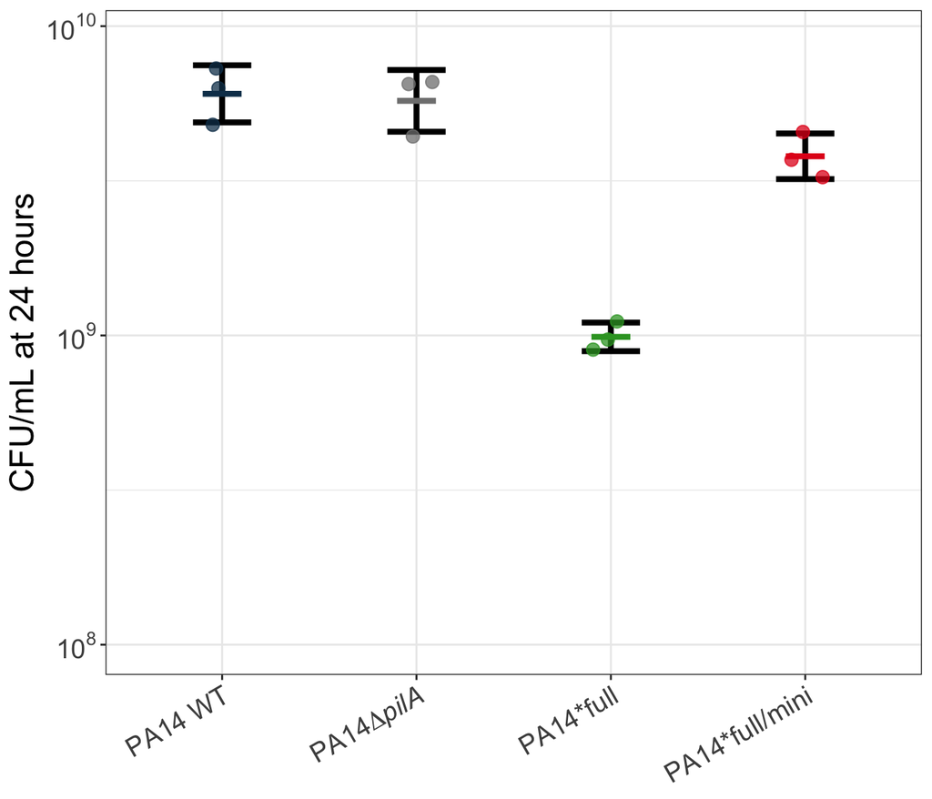

```r
cfu_stat_plot2
```

```r
ggsave(cfu_stat_plot2, filename = "./figures/growth_curve_CFU_mL_stat_rev.png", width = unit(4,"cm"), height = unit(4,"cm"), dpi = 300)

ggsave(cfu_stat_plot2, filename = "./figures/growth_curve_CFU_mL_stat_rev.svg", width = unit(4,"cm"), height = unit(4,"cm"), dpi = 300)
```

# 5 Competition assay

## 5.1 Prepare data

Read csv file

```r
#data of all
fa <-  read.csv("./competition_assay/fitness_assay_new_G1_all.csv")
```

Clean dataframe

```r
lac <- fa %>%
  subset(Hours==24) %>%
  subset(Lac_marker=="Lac Ancestor" | Lac_marker=="delPf5")
lac$Selection_rate_cheater <- lac$Selection_rate_comp
lac$Cheater_proportion_i <- lac$Comp_proportion_i
lac$Cheater <- "PA14 WT"

g <- fa %>%
  subset(Hours==24) %>%
  subset(Lac_marker=="new G1")
g$Selection_rate_cheater <- g$Selection_rate_lac
g$Cheater_proportion_i <- g$Lac_proportion_i
g$Cheater <- "PA14*full/mini"

b <- fa %>%
  subset(Hours==24) %>%
  subset(Lac_marker=="B1")
b$Selection_rate_cheater <- b$Selection_rate_lac
b$Cheater_proportion_i <- b$Lac_proportion_i
b$Cheater <- "PA14*full"

glac <- rbind(g,b,lac)
glac$Selection_rate_cheater <- as.numeric(glac$Selection_rate_cheater)
```

## 5.2 Figure

### 5.2.1 net fitness

```r
glac2 <- glac %>%
  mutate(Competitor = ifelse(Competitor == "PA14 Ancestor", "PA14 WT", Competitor))
glac2[which(glac2$Lac_marker == "delPf5"), "Cheater"] <- "PA14 delPf5"

glac2$Cheater = factor(glac2$Cheater, levels=c("PA14 WT", "PA14*full", "PA14*full/mini", "PA14 delPf5"), ordered = TRUE, labels = c("<b>PA14 WT</b>", "<b>PA14*full</b>", "<b>PA14*full/mini</b>", "<b>PA14&Delta;Pf5</b>"))

glac2$Competitor = factor(glac2$Competitor, levels=c("PA14 WT", "PA14 pilA"), ordered = TRUE, labels = c("<b>PA14 WT</b>", "<b>PA14&Delta;<i>pilA</i></b>"))


all_comp2 <- ggplot(glac2, aes(x = Cheater_proportion_i, y = Selection_rate_cheater, fill = Pop_CFU_f, group=Cheater))+
  geom_smooth(method=lm, formula = y ~ x, color="black", fill="grey40")+
  geom_point(color="black",size=3, shape=21)+
  scale_fill_gradientn(colours = viridis(256, option = "H"), trans = "log", breaks = c(1e7, 1e8, 1e9, 1e10), limits = c(1e7, 1e10))+
  labs(x="Competitor initial proportion", y="Net fitness advantage of competitor", fill="Final Population\n(CFU/mL)")+
  geom_hline(yintercept = 0)+
  theme_bw()+
  scale_x_continuous(limits = c(0,1), breaks = c(0,0.5,1))+
  scale_y_continuous(limits = c(-5,11), breaks = c(-5,0,5,10))+
  theme(
    axis.title = element_text(size=24),
    axis.text.x = element_text(size = 22),
    axis.text.y = element_text(size = 22),
    legend.position = "top",
    legend.key.width = unit(3, "cm"),
    legend.title = element_text(size=20),
    legend.text = element_text(hjust=0,size=20),
    strip.text = element_markdown(size=20, margin = margin(0.2,0.1,0.1,0.1, "cm"), hjust=0.5, vjust=0.5),
    strip.text.x = element_markdown(size = 22, hjust=0.5, vjust=0.5),
  strip.text.y = element_markdown(size = 22, hjust=0.5, vjust=0.5),
  strip.placement = "inside",
  panel.spacing.x = unit(8, "mm"),
  panel.grid.minor = element_blank()
    )
```

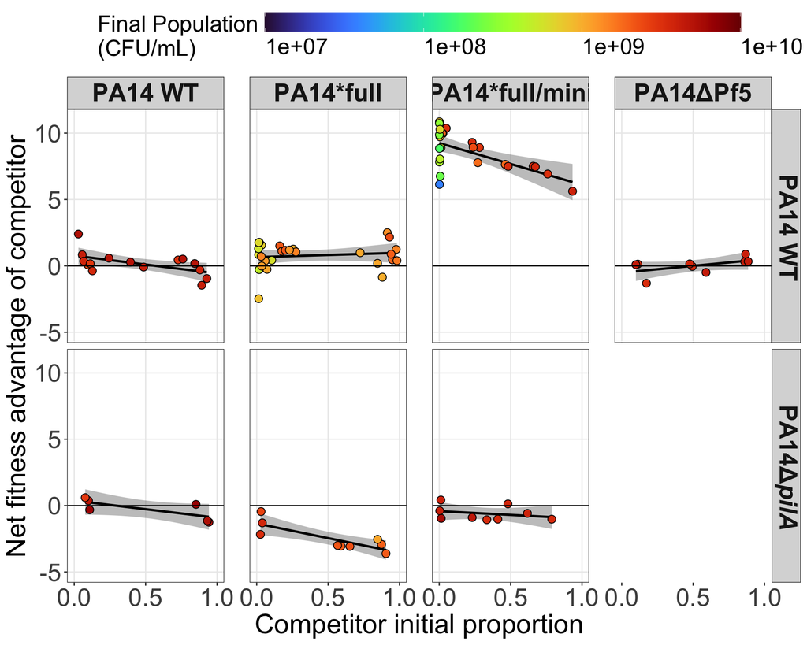

```r
all_comp3 <- all_comp2 + facet_grid2(Competitor~Cheater, scales = "free_x", render_empty = FALSE)
all_comp3
```

```r
ggsave(plot=all_comp3, "./figures/net_fitness_rev.png", height = 7.5, width = 16, dpi = 300)
ggsave(plot=all_comp3, "./figures/net_fitness_rev.svg", height = 7.5, width = 16, dpi = 300)
```

### 5.2.2 timepoints with WT

Used washed pellet

```r
tp <- read.csv("./competition_assay/fitness_assay_newG1_timepoint_wash_pellet.csv")
```

```r
#subset and wide to long
all_tp_long <- tp %>%
  pivot_longer(cols =c(Lac_CFU, Comp_CFU), names_to = "CFU_strain", values_to = "CFU")

all_tp_long$strain <- NA
for (i in 1:nrow(all_tp_long)) {
  s_i <- all_tp_long$CFU_strain[i]
  if(s_i == "Lac_CFU"){
    all_tp_long$strain[i] <- all_tp_long$Lac_marker[i]
  }
  if(s_i == "Comp_CFU"){
    all_tp_long$strain[i] <- all_tp_long$Competitor[i]
  }
}

all_tp_long$id <- paste(all_tp_long$Competitions, all_tp_long$Frequency, all_tp_long$Replicate, all_tp_long$strain, sep = "_")

all_tp_long$Replicate <- as.factor(all_tp_long$Replicate)

all_tp_long$label <- NA
all_tp_long[which(all_tp_long$strain=="PA14 Ancestor"),"label"] <- "PA14 WT"
all_tp_long[which(all_tp_long$strain=="Lac Ancestor"),"label"] <- "PA14 WT "
all_tp_long[which(all_tp_long$strain=="B1"),"label"] <- "PA14*full"
all_tp_long[which(all_tp_long$strain=="new G1"),"label"] <- "PA14*full/mini"

all_tp_long$Frequency_f = factor(all_tp_long$Frequency, levels=c("1:9", "9:1"))
levels(all_tp_long$Frequency_f) = c("1:9"="<b><i>pf5r</i> rare</b>", "9:1"="<b><i>pf5r</i> 1:1</b>")

all_tp_long$Lac_marker_f = factor(all_tp_long$Lac_marker, levels=c("Lac Ancestor", "B1", "new G1"))
levels(all_tp_long$Lac_marker_f) = c("Lac Ancestor"="<b>PA14 WT</b>", "B1"="<b>PA14*full</b>", "new G1"="<b>PA14*full/mini</b>")
```

Average

Plot without ancestor control

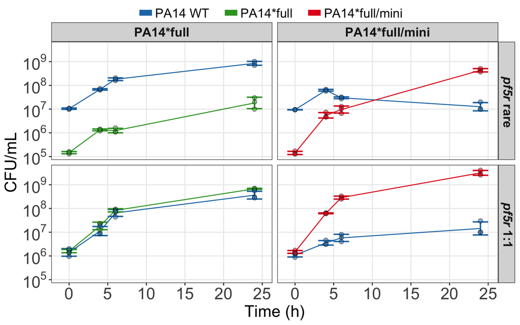

```r
all_tp_long_no_anc <- all_tp_long %>%
  filter(Lac_marker != "Lac Ancestor")

tp_plot_avg_no_anc <- ggplot(all_tp_long_no_anc, aes(x=Hour, y=CFU, group=label, color=label, fill=label)) +
  stat_summary(fun=mean, geom = "line")+
  stat_summary(fun.min=function(y)(mean(y)-sd(y)),
               fun.max=function(y)(mean(y)+sd(y)),
               geom="errorbar", width=2, size=0.75) +
  geom_point(shape=21, alpha = 0.5, size=2, color="black", show.legend = FALSE)+
  facet_grid(Frequency_f~Lac_marker_f) +
  scale_color_manual(values = col_hex2, drop=F)+
  scale_fill_manual(values = col_hex2, drop=F)+
  scale_y_log10(breaks = trans_breaks("log10", function(x) 10^x),labels = trans_format("log10", math_format(10^.x))) +
  # scale_y_continuous(trans = 'log10')+
  labs(y="CFU/mL", x="Time (h)", color="Strains")+
  theme_bw()+
  guides(colour = guide_legend(override.aes = list(linewidth = 3)))+
  theme(
    # text = element_text(size = 8),
    legend.text = element_text(hjust=0,size=14, margin = margin(r = 10, l=2, unit = "pt")),
    axis.text.x = element_text(size = 18),
    axis.text.y = element_text(size = 18),
    axis.title = element_text(size=18),
    strip.text = element_markdown(size=14, margin = margin(0.2,0.1,0.1,0.1, "cm"), hjust=0.5, vjust=0.5),
    strip.text.x = element_markdown(size = 14, hjust=0.5, vjust=0.5),
  strip.text.y = element_markdown(size = 14, hjust=0.5, vjust=0.5),
  strip.placement = "inside",
  legend.margin=margin(0,0,1,0),
  legend.box.margin=margin(0,0,1,0),
  legend.box.spacing = unit(0, "pt"),
  legend.position = "top",
  legend.title = element_blank(),
  panel.grid.minor = element_blank(),
  # legend.key.width = unit(0.4, "lines"),
  legend.spacing.y = unit(3, "lines")
)
tp_plot_avg_no_anc
```

```r
ggsave(plot=tp_plot_avg_no_anc, filename = "./figures/competition_timepoint_avg_WT_rev.png", units = "cm", height = 12, width = 16, dpi = 300)

ggsave(plot=tp_plot_avg_no_anc, filename = "./figures/competition_timepoint_avg_WT_rev.svg", units = "cm", height = 12, width = 16, dpi = 300)
```

### 5.2.3 timepoints with pilA

```r
pilA_tp <-  read.csv("./competition_assay/fitness_assay_pilA_timepoint.csv")
```

```r
#subset and wide to long
pilA_tp_long <- pilA_tp %>%
  filter(Frequency == "1:9" | Frequency == "9:1") %>%
  pivot_longer(cols =c(Lac_CFU, Comp_CFU), names_to = "CFU_strain", values_to = "CFU")

pilA_tp_long$strain <- NA
for (i in 1:nrow(pilA_tp_long)) {
  s_i <- pilA_tp_long$CFU_strain[i]
  if(s_i == "Lac_CFU"){
    pilA_tp_long$strain[i] <- pilA_tp_long$Lac_marker[i]
  }
  if(s_i == "Comp_CFU"){
    pilA_tp_long$strain[i] <- pilA_tp_long$Competitor[i]
  }
}

pilA_tp_long$id <- paste(pilA_tp_long$Competitions, pilA_tp_long$Frequency, pilA_tp_long$Replicate, pilA_tp_long$strain, sep = "_")

pilA_tp_long$Replicate <- as.factor(pilA_tp_long$Replicate)

pilA_tp_long$label = factor(pilA_tp_long$strain, levels=c("Lac Ancestor", "PA14 pilA", "B1", "new G1"))
exprvec <- c("PA14 WT", "PA14&Delta;<i>pilA</i>", "PA14*full", "PA14*full/mini")

pilA_tp_long$Frequency_f = factor(pilA_tp_long$Frequency, levels=c("1:9", "9:1"))
levels(pilA_tp_long$Frequency_f) = c("1:9"="<b><i>pf5r</i> rare</b>", "9:1"="<b><i>pf5r</i> 1:1</b>")

pilA_tp_long$Lac_marker_f = factor(pilA_tp_long$Lac_marker, levels=c("Lac Ancestor", "B1", "new G1"))
levels(pilA_tp_long$Lac_marker_f) = c("Lac Ancestor"="<b>PA14 WT</b>", "B1"="<b>PA14*full</b>", "new G1"="<b>PA14*full/mini</b>")
```

plot

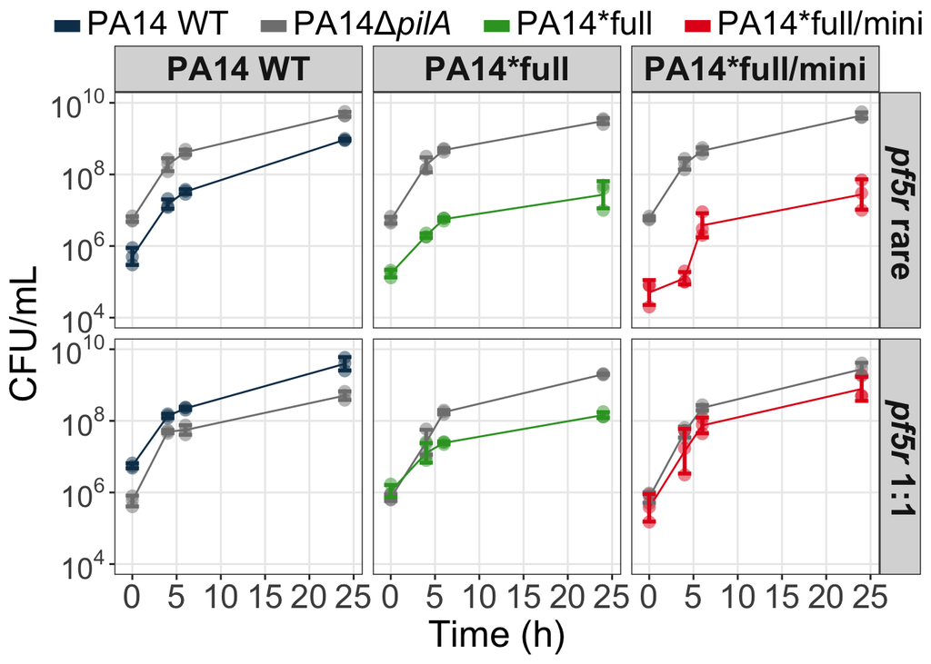

```r
pilA_tp_plot_avg <- ggplot(pilA_tp_long, aes(x=Hour, y=CFU, group=label, color=label)) +
  # geom_line()+
  geom_point(show.legend =FALSE, alpha=0.5, shape=16, size=3)+
  stat_summary(fun=mean, geom = "line")+
  stat_summary(fun.min=function(y)(mean(y)-sd(y)),
               fun.max=function(y)(mean(y)+sd(y)),
               geom="errorbar", width=1.5, size=1) +
  facet_grid(Frequency_f~Lac_marker_f) +
  scale_color_manual(values = col_hex, drop=F, labels=exprvec)+
  scale_y_log10(breaks = c(1e4, 1e6, 1e8, 1e10),labels = trans_format("log10", math_format(10^.x)), limits = c(1e4,1e10)) +
  labs(y="CFU/mL", x="Time (h)", color="Strains")+
  theme_bw()+
  guides(colour = guide_legend(override.aes = list(linewidth = 3)))+
  theme(
    axis.text.x = element_text(size = 18),
    axis.text.y = element_text(size = 16),
    axis.title = element_text(size=20),
    strip.text = element_markdown(size=18, margin = margin(0.2,0.1,0.1,0.1, "cm"), hjust=0.5, vjust=0.5),
    strip.text.x = element_markdown(size = 18, hjust=0.5, vjust=0.5),
  strip.text.y = element_markdown(size = 18, hjust=0.5, vjust=0.5),
  strip.placement = "inside",
  legend.margin=margin(0,0,1,0),
  legend.box.margin=margin(0,0,1,0),
  legend.box.spacing = unit(0, "pt"),
  legend.position = "top",
  legend.title = element_blank(),
  legend.text = element_markdown(hjust=0, size=18, margin = margin(r = 10, l=2, unit = "pt")),
  panel.grid.minor = element_blank(),
  # legend.key.width = unit(0.4, "lines"),
  legend.spacing.y = unit(3, "lines")
    )

pilA_tp_plot_avg
```

Save plot

```r
ggsave(plot=pilA_tp_plot_avg, filename = "./figures/competition_timepoint_avg_pilA_rev.png", units = "cm", height = 14, width = 25, dpi=300)

ggsave(plot=pilA_tp_plot_avg, filename = "./figures/competition_timepoint_avg_pilA_rev.svg", units = "cm", height = 14, width = 25, dpi = 300)
```

# 6 Twitch

## 6.1 Prepare data

```r
twitch <- read.csv("./twitch_assay/fitness_assay_newG1_twitch.csv") %>%
  filter(
    Freq == "1:9" | Freq == "9:1",
    Competition == "PA14 Ancestor vs new G1" | Competition == "PA14 Ancestor vs B1"
    ) %>%
  mutate(
    Time_h = factor(Time_h),
    strain_l = case_match(
      Strain,
      "PA14 Ancestor" ~ "PA14 WT",
      "B1" ~ "PA14*full",
      "new G1" ~ "PA14*full/mini"
    ),
    strain_l = factor(strain_l, levels = c("PA14*full", "PA14*full/mini", "PA14 WT")),
    comp_f = case_match(
      Competition,
      "PA14 Ancestor vs B1" ~ "PA14*full vs PA14 WT",
      "PA14 Ancestor vs new G1" ~ "PA14*full/mini vs PA14 WT"
    ),
    comp_f = factor(comp_f, levels = c("PA14*full vs PA14 WT", "PA14*full/mini vs PA14 WT"))
  )

twitch2 <- twitch %>%
  mutate(
    comp_wrap = case_match(
      comp_f,
      "PA14*full vs PA14 WT" ~ "PA14*full\nvs\nPA14 WT",
      "PA14*full/mini vs PA14 WT" ~ "PA14*full/mini\nvs\nPA14 WT"
    ),
    label = paste0(strain_l, " ", Time_h, "h", "\n", comp_f),
    time_comp = interaction(Time_h, comp_f, sep = "!")
  )
```

## 6.2 Figures

```r
time_stat <- twitch2 %>%
  group_by(comp_f, Time_h) %>%
  wilcox_test(Twitch_mm ~ strain_l, paired = FALSE)%>%
  adjust_pvalue(method = "bonferroni") %>%
  add_xy_position(x = "Time_h", dodge = 0.75)%>%
  add_significance() %>%
  mutate(
    #make lines in right facet same length as left
    xmin = case_match(
      Time_h,
      "0" ~ 0.7333333,
      "24" ~ 1.7333333
    )
  )
```

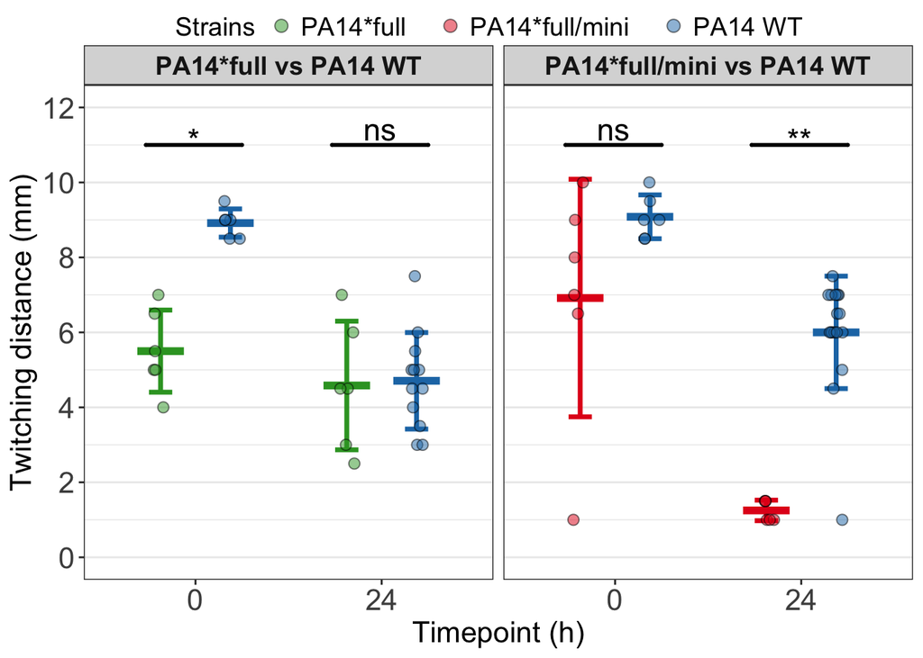

```r
twitch_time_plot <- ggplot(twitch2, aes(x=Time_h, y=Twitch_mm, group = strain_l, color = strain_l, fill = strain_l))+
  stat_summary(fun.min=function(y)(mean(y)-sd(y)),
               fun.max=function(y)(mean(y)+sd(y)),
               geom="errorbar", width = 0.25, position = position_dodge(w = 0.75), show.legend = FALSE, linewidth=1.25)+
  stat_summary(fun=base::mean, geom="crossbar", fatten = 4, width = 0.5, position = position_dodge(w = 0.75), show.legend = FALSE)+
  geom_point(alpha=0.5, position = position_jitterdodge(dodge.width=0.75, jitter.width = 0.25), size=2.5, color="black", shape=21)+
  facet_wrap(vars(comp_f))+
  stat_pvalue_manual(
    time_stat, label = "{p.adj.signif}",
    y.position = c(11,11,11,11),
    tip.length = 0,
    bracket.size=1,
    size=6,
    show.legend = FALSE
    )+
  scale_color_manual(values = col_hex2)+
  scale_fill_manual(values = col_hex2)+
  labs(x="Timepoint (h)", y="Twitching distance (mm)", fill="Strains")+
  scale_y_continuous(limits = c(0,12), breaks = seq(0,12,2))+
  theme_bw()+
  guides(fill = guide_legend(override.aes = list(size=3)), color = guide_legend(override.aes = list(linetype = 0)), shape="none")+
  theme(
    panel.grid.major.x = element_blank(),
    panel.grid.minor.x = element_blank(),
    axis.title.y = element_text(size=16),
    axis.title.x = element_text(size=16),
    axis.text = element_text(size=16),
    axis.text.x = element_text(size=16, hjust = 0.5, vjust = 1),
    axis.text.x.bottom = element_text(size=16),
    text = element_text(size = 16),
    strip.text = element_text(size=14, face = "bold"),
    legend.title = element_text(size=14),
    legend.text = element_text(size=14, margin = margin(r = 10, l=2, unit = "pt")),
    legend.position = "top",
    legend.margin=margin(0,0,1,0),
  legend.box.margin=margin(0,0,1,0),
  legend.box.spacing = unit(0, "pt")
    )
twitch_time_plot
```

```r
ggsave(plot = twitch_time_plot, "./figures/twitch_rev.png", units = "cm", height = 10, width = 16, device = "png", dpi = 300)
ggsave(plot = twitch_time_plot, "./figures/twitch_rev.svg", units = "cm", height = 10, width = 16, device = "svg", dpi = 300)
```

# 7 qPCR

## 7.1 Prepare Data

Read in standard curve data

```r
std_curve <- read.csv("./qPCR/std_curve.csv")

pflM <- std_curve %>%
  filter(sample == "p")
pflm_lm <- lm(data = pflM, CT_num~count_num)

zot_cap <- std_curve %>%
  filter(sample == "zc")
zc_lm <- lm(data = zot_cap, CT_num~count_num)
```

Read qPCR data

```r
#overnights
on_qpcr <- read.csv("./qPCR/overnight_qpcr.csv")

#timepoints
qpcr_data <- read.csv("./qPCR/qPCR_data.csv")
```

## 7.2 overnight

```r
on <- on_qpcr %>%
  separate(Sample.Name, into = c("sample", "biorep"), sep = "(?<=[A-Za-z])(?=[0-9])") %>%
  mutate(
    CT_num = as.numeric(ifelse(CT == "Undetermined", NA, CT)),
    dil_log10copies = (CT_num - pflm_lm$coefficients[[1]]) / pflm_lm$coefficients[[2]],
    dil_copies = (10^dil_log10copies),
    copies = dil_copies * 10,
    log10copies = log10(copies),
    dnase_vol_uL = 89, #supernatant volume (uL) that was DNase treated
    rxn_vol_uL = 100, #total dnase reaction volume (uL)
    multiplier = 1/(dnase_vol_uL/rxn_vol_uL), # total rxn solution to supernatant ratio (1:0.89)
    qpcr_vol_uL = 2, #treated supernatant volume (uL) used in qPCR
    phage_uL = (copies / qpcr_vol_uL) * multiplier, #copy number of phage per uL
    phage_mL = phage_uL * 1000,
    sample_label = case_match(
      sample,
      "f" ~ "PA14*full",
      "fm" ~ "PA14*full/mini",
      "WT" ~ "PA14 WT",
    )
    ) %>%
  group_by(sample, biorep) %>%
  filter(
    #remove outliers
    log10copies >= quantile(log10copies, 0.25) - 1.5 * IQR(log10copies),
    log10copies <= quantile(log10copies, 0.75) + 1.5 * IQR(log10copies)
  ) %>%
  ungroup()


#remove bio reps with not enough technical replicates
on_sub <- on %>%
  group_by(sample, biorep) %>%
  filter(n() > 2) %>%
  ungroup() %>%
  mutate(
    #since biorep 2 for WT was removed, rename biorep 3 as 2 to prevent skipped numbering
    biorep = ifelse(sample == "WT" & biorep==3, 2, biorep)
  )
```

## 7.3 timepoint

Clean data by:

- Removing outliers (most likely pipetting error)
- Relabeling sample and target name to a clearer description
- Calculate for actual copy number per mL given that 2uL of DNase-treated supernatant was used in qPCR reaction (DNase treatment also dilutes supernatant by 0.89; total reaction volume 100uL = 89uL supernatant + 1uL DNase + 10uL DNAse buffer)

```r
all_combine <- qpcr_data %>%
  #remove outliers (most likely pipetting error)
  group_by(Target.Name, hour_num, sample) %>%
  filter(
    log10copies >= quantile(log10copies, 0.25) - 1.5 * IQR(log10copies),
    log10copies <= quantile(log10copies, 0.75) + 1.5 * IQR(log10copies),
  ) %>%
  ungroup() %>%
  mutate(
    dnase_vol_uL = 89, #supernatant volume (uL) that was DNase treated
    rxn_vol_uL = 100, #total dnase reaction volume (uL)
    multiplier = 1/(dnase_vol_uL/rxn_vol_uL), # total rxn solution to supernatant ratio (1:0.89)
    qpcr_vol_uL = 2, #treated supernatant volume (uL) used in qPCR
    phage_uL = (copies / qpcr_vol_uL) * multiplier, #copy number of phage per uL
    phage_mL = phage_uL * 1000,
    rep_label=case_match(
      sample,
      "B1" ~ "Replicate 1",
      "B2" ~ "Replicate 2",
      "B3" ~ "Replicate 3",
      "B4" ~ "Replicate 4",
      "B5" ~ "Replicate 5"
    ),
    target_label=case_match(
      Target.Name,
      "pflM2" ~ "total phage population",
      "zot-cap" ~ "full-length phage"
    ),
    target_label=factor(target_label, levels = c("total phage population", "full-length phage"))
  )
```

## 7.4 stats

### 7.4.1 change in total phage population

Average tech rep and aggregate bio reps together

```r
all_bio_avg <- all_combine %>%
  group_by(rep_label, target_label, hour_num) %>%
  summarise(
    mean = mean(phage_mL),
    sd = sd(phage_mL),
     .groups = "drop"
    ) %>%
  filter(
    hour_num %in% c(24,48,72)
  )%>%
  mutate(
    hour_f = factor(hour_num, levels = c("24", "48", "72")),
    log10_mean = log10(mean)
  )
```

### 7.4.2 total pop calc

```r
tot_bio_avg <- all_bio_avg %>%
  filter(target_label == "total phage population")%>%
  droplevels()
```

check p-value for one way repeated measures anova (p=0.000429)

```r
#one way repeated measures anova
aov_model = aov(data = tot_bio_avg, log10_mean ~ hour_f + Error(rep_label/hour_f))
summary(aov_model)
```

```
##
## Error: rep_label
##           Df Sum Sq Mean Sq F value Pr(>F)
## Residuals  4  3.755  0.9388
##
## Error: rep_label:hour_f
##           Df Sum Sq Mean Sq F value   Pr(>F)
## hour_f     2  10.41   5.205    23.8 0.000429 ***
## Residuals  8   1.75   0.219
## ---
## Signif. codes:  0 '***' 0.001 '**' 0.01 '*' 0.05 '.' 0.1 ' ' 1
```

Check assumptions for one way repeated measures anova:

- normal distribution
- sphericity

Note: no need to do levene’s test for repeated one way anova b/c variances between groups are not independent (each rep has a datapoint in a timepoint); more important to look at sphericity (variances of the differences between all combinations of timepoints are equal)

Check normal distribution

```r
tot_bio_avg %>%
  group_by(hour_f) %>%
  shapiro_test(log10_mean) #normal distribution (p>0.05)
```

```
## # A tibble: 3 × 4
##   hour_f variable   statistic     p
##   <fct>  <chr>          <dbl> <dbl>
## 1 24     log10_mean     0.930 0.595
## 2 48     log10_mean     0.911 0.474
## 3 72     log10_mean     0.897 0.395
```

check sphericity

```r
res.aov <- anova_test(data = tot_bio_avg, dv = log10_mean, wid = rep_label, within = hour_f)
res.aov #sphericity; p>0.05 for Mauchly's test so variances of group differences are equal
```

```
## ANOVA Table (type III tests)
##
## $ANOVA
##   Effect DFn DFd      F        p p<.05   ges
## 1 hour_f   2   8 23.798 0.000429     * 0.654
##
## $`Mauchly's Test for Sphericity`
##   Effect     W     p p<.05
## 1 hour_f 0.574 0.434
##
## $`Sphericity Corrections`
##   Effect   GGe    DF[GG] p[GG] p[GG]<.05   HFe     DF[HF]    p[HF] p[HF]<.05
## 1 hour_f 0.701 1.4, 5.61 0.002         * 0.964 1.93, 7.72 0.000527         *
```

check pairwise comparison

```r
pwc <- tot_bio_avg %>%
  pairwise_t_test(
    log10_mean ~ hour_f, paired = TRUE,
    p.adjust.method = "bonferroni"
    ) %>%
  add_xy_position(x = "hour_f") %>%
  mutate(
    #for plotting, adjust y-position of bracket
    y.position = ifelse(groups == 'c("48", "72")', 10.5, y.position)
  )

pwc
```

```
## # A tibble: 3 × 14
##   .y.        group1 group2    n1    n2 statistic    df     p p.adj p.adj.signif
##   <chr>      <chr>  <chr>  <int> <int>     <dbl> <dbl> <dbl> <dbl> <chr>
## 1 log10_mean 24     48         5     5      1.95     4 0.123 0.369 ns
## 2 log10_mean 24     72         5     5      5.78     4 0.004 0.013 *
## 3 log10_mean 48     72         5     5      7.71     4 0.002 0.005 **
## # ℹ 4 more variables: y.position <dbl>, groups <named list>, xmin <dbl>,
## #   xmax <dbl>
```

### 7.4.3 full-length freq

Calculate frequency of full-length phage (mean of full-length phage / mean of total phage population)

```r
full_bio_avg <- all_bio_avg %>%
  pivot_wider(id_cols = c("rep_label", "hour_f"), names_from = target_label, values_from = mean) %>%
  rename(
    full_mean = "full-length phage",
    tot_pop_mean = "total phage population"
    ) %>%
  mutate(
    full_freq = (full_mean / tot_pop_mean) * 100
  )
```

Do one-way repeated measures anova and check assumptions p=0.00229

```r
#one way repeated anova
aov_model = aov(data = full_bio_avg, full_freq ~ hour_f + Error(rep_label/hour_f))
summary(aov_model)
```

```
##
## Error: rep_label
##           Df Sum Sq Mean Sq F value Pr(>F)
## Residuals  4  97.75   24.44
##
## Error: rep_label:hour_f
##           Df Sum Sq Mean Sq F value  Pr(>F)
## hour_f     2 1621.7   810.8   14.28 0.00229 **
## Residuals  8  454.2    56.8
## ---
## Signif. codes:  0 '***' 0.001 '**' 0.01 '*' 0.05 '.' 0.1 ' ' 1
```

```r
full_bio_avg %>%
  group_by(hour_f) %>%
  shapiro_test(full_freq) #normal distribution (p>0.05)
```

```
## # A tibble: 3 × 4
##   hour_f variable  statistic     p
##   <fct>  <chr>         <dbl> <dbl>
## 1 24     full_freq     0.939 0.656
## 2 48     full_freq     0.831 0.142
## 3 72     full_freq     0.908 0.454
```

```r
res.aov <- anova_test(data = full_bio_avg, dv = full_freq, wid = rep_label, within = hour_f)
res.aov #sphericity; p>0.05 for Mauchly's test so variances of group differences are equal
```

```
## ANOVA Table (type III tests)
##
## $ANOVA
##   Effect DFn DFd      F     p p<.05   ges
## 1 hour_f   2   8 14.282 0.002     * 0.746
##
## $`Mauchly's Test for Sphericity`
##   Effect     W    p p<.05
## 1 hour_f 0.438 0.29
##
## $`Sphericity Corrections`
##   Effect  GGe     DF[GG] p[GG] p[GG]<.05   HFe     DF[HF] p[HF] p[HF]<.05
## 1 hour_f 0.64 1.28, 5.12 0.011         * 0.809 1.62, 6.48 0.005         *
```

check pairwise comparison

```r
pwc2 <- full_bio_avg %>%
  pairwise_t_test(
    full_freq ~ hour_f, paired = TRUE,
    p.adjust.method = "bonferroni"
    ) %>%
  add_xy_position(x = "hour_f") %>%
  mutate(
    y.position = case_when(
      groups=='c("24", "48")' ~ 43,
      groups=='c("48", "72")' ~ 41,
      groups=='c("24", "72")' ~ 48,
      )
  )
pwc2
```

```
## # A tibble: 3 × 14
##   .y.       group1 group2    n1    n2 statistic    df     p p.adj p.adj.signif
##   <chr>     <chr>  <chr>  <int> <int>     <dbl> <dbl> <dbl> <dbl> <chr>
## 1 full_freq 24     48         5     5      2.88     4 0.045 0.134 ns
## 2 full_freq 24     72         5     5      5.51     4 0.005 0.016 *
## 3 full_freq 48     72         5     5      2.17     4 0.095 0.286 ns
## # ℹ 4 more variables: y.position <dbl>, groups <named list>, xmin <dbl>,
## #   xmax <dbl>
```

## 7.5 Figure

### 7.5.1 overnight

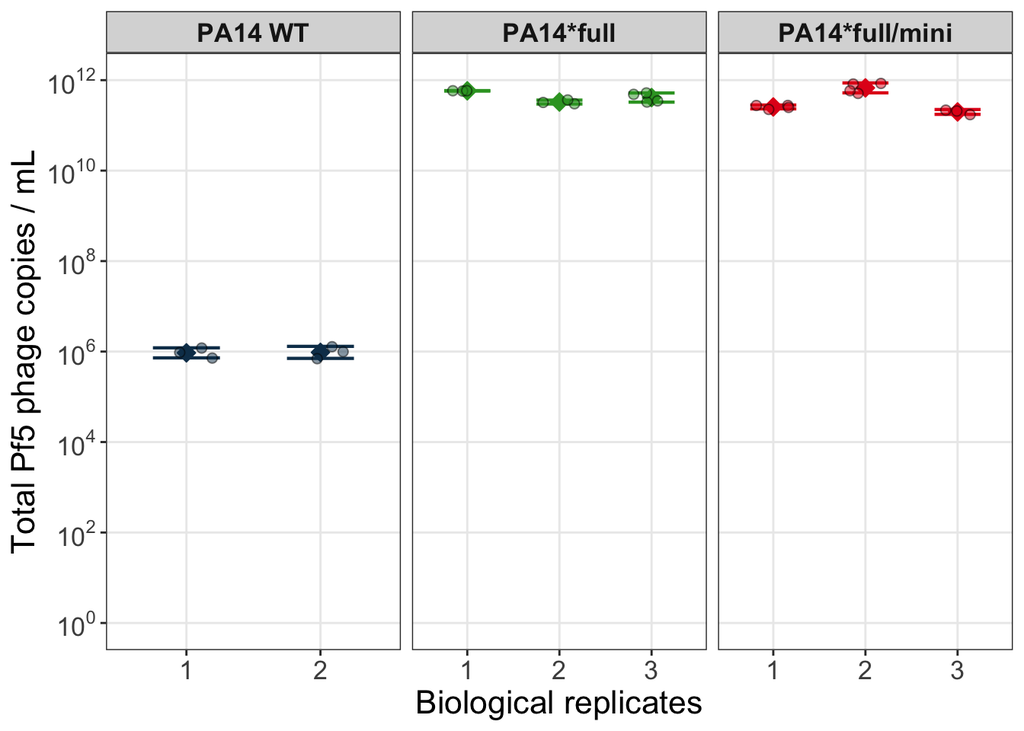

```r
on_sub_plot <- ggplot(on_sub, aes(x=biorep, y=phage_mL, group = biorep, color=sample_label, fill=sample_label))+
  stat_summary(fun=mean, geom="point", shape=23, size=3, show.legend = FALSE)+
  stat_summary(fun.min=function(y)(mean(y)-sd(y)),
               fun.max=function(y)(mean(y)+sd(y)),
               geom="errorbar", width=0.5, linewidth=0.75) +
  geom_point(alpha=0.5, shape=21, size=2, color="black", position = position_jitter(w=0.2, h=0))+
  facet_grid(cols=vars(sample_label), scales="free")+
  scale_y_log10(breaks = trans_breaks("log10", function(x) 10^x),
              labels = trans_format("log10", math_format(10^.x)),
              limits = c(1,1e12))+
  scale_color_manual(values = c("#0F3C59", "#33A02C", "#E31A1C"))+
  scale_fill_manual(values = c("#0F3C59", "#33A02C", "#E31A1C"))+
  labs(x= "Biological replicates", y="Total Pf5 phage copies / mL")+
  theme_bw()+
  theme(
    panel.grid.minor = element_blank(),
    legend.position = "none",
    strip.text = element_text(face = "bold"),
    text = element_text(size = 16),
    )
on_sub_plot
```

save

```r
ggsave(plot = on_sub_plot, filename = "./figures/qPCR_overnight.png", width = 5, height = 4)

ggsave(plot = on_sub_plot, filename = "./figures/qPCR_overnight.svg", width = 5, height = 4)

# ggsave(plot = on_sub_plot, filename = "./figures/qPCR_overnight.pdf", width = 5, height = 4)
```

### 7.5.2 timepoints

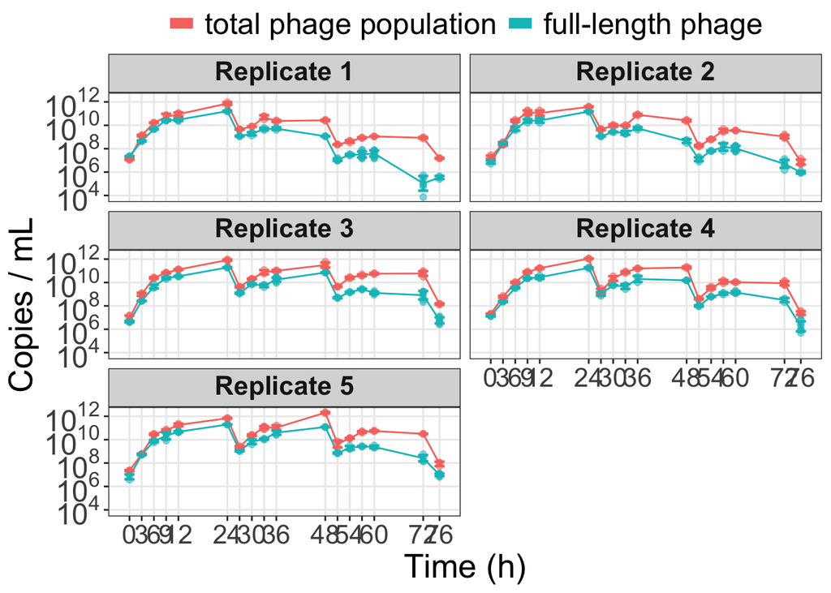

```r
pfu_mL_plot <- ggplot(all_combine, aes(x = hour_num, y=phage_mL, color=target_label, group = target_label))+
  geom_point(size=1.5, alpha=0.5)+
  facet_wrap(~rep_label, ncol=2)+
  stat_summary(fun=mean, geom = "line")+
  stat_summary(fun.min=function(y)(mean(y)-sd(y)),
               fun.max=function(y)(mean(y)+sd(y)),
               geom="errorbar", width=2.5, linewidth=0.75) +
  labs(x= "Time (h)", y="Copies / mL", color="Target")+
  scale_y_log10(breaks = trans_breaks("log10", function(x) 10^x),
              labels = trans_format("log10", math_format(10^.x))) +
  scale_x_continuous(breaks = c(0,3,6,9,12,24,27,30,33,36,48,51,54, 57, 60,72,76), labels = c(0,3,6,9,12,24,"",30,"",36,48,"",54,"",60,72,76))+
  guides(colour = guide_legend(override.aes = list(linewidth = 3))) +
  theme_bw()+
  theme(
    legend.position = "top",
    legend.title = element_blank(),
    legend.text = element_text(size=18),
    legend.margin=margin(0,0,5,0),
    legend.box.margin=margin(0,0,5,0),
    legend.box.spacing = unit(0, "pt"),
    # text = element_text(size = 16),
    panel.grid.minor = element_blank(),
    axis.title.x = element_text(size=20),
    axis.title.y = element_text(size=20),
    axis.text.x = element_text(size = 16),
    axis.text.y = element_text(size=18),
    strip.text = element_markdown(face = "bold", size=16)
  )
pfu_mL_plot
```

save

```r
ggsave(plot = pfu_mL_plot, filename = "./figures/qPCR_copies_timepoint.png", width = 30, height = 22, units = "cm", dpi=600)
ggsave(plot = pfu_mL_plot, filename = "./figures/qPCR_copies_timepoint.svg", width = 30, height = 22, units = "cm", dpi=600)
```

### 7.5.3 stats total population

plot comparison of total phage population between 24h, 48h, and 72h. Add statistical significance.

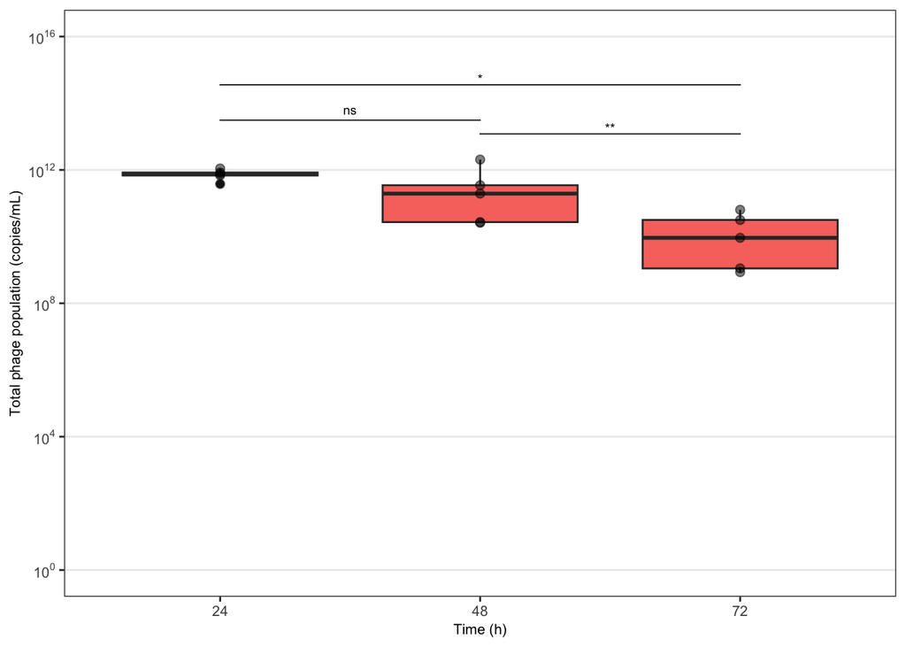

```r
tot_bio_avg_plot <- ggplot(tot_bio_avg, aes(x = hour_f, y = mean))+
  geom_boxplot(fill="#F8766D")+
  geom_point(alpha=0.5, size=2)+
  scale_y_log10(
    breaks = c(1, 1e4, 1e8, 1e12, 1e16),
    labels = trans_format("log10", math_format(10^.x)),
    limits=c(1,1e16)
    )+
  stat_pvalue_manual(
    pwc,
    bracket.nudge.y = 1,
    step.increase = 0.07,
    tip.length = 0,
    size=2.5
    ) +
  labs(x= "Time (h)", y="Total phage population (copies/mL)")+
  theme_bw()+
  theme(
    panel.grid.minor = element_blank(),
    panel.grid.major.x = element_blank(),
    axis.title = element_text(size=8),
    axis.text.x = element_text(size = 8),
    axis.text.y = element_text(size=8),
    legend.position = "none"
  )
tot_bio_avg_plot
```

save

```r
ggsave(plot = tot_bio_avg_plot, filename = "./figures/qPCR_total_pop_anova.png", width = 6, height = 6, units = "cm")

ggsave(plot = tot_bio_avg_plot, filename = "./figures/qPCR_total_pop_anova.svg", width = 6, height = 6, units = "cm")
```

### 7.5.4 stats full-length phage

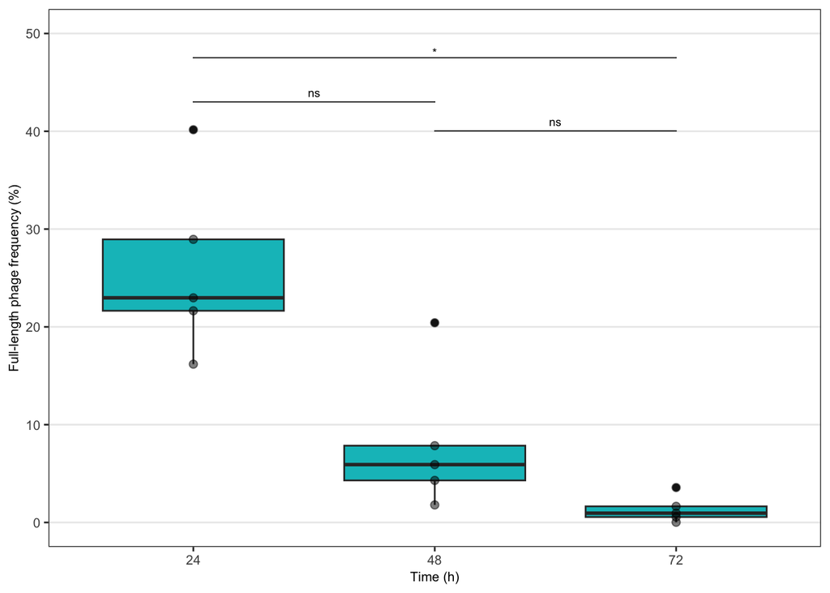

```r
full_bio_avg_plot <- ggplot(full_bio_avg, aes(x = hour_f, y = full_freq))+
  geom_boxplot(fill="#00BFC4")+
  geom_point(alpha=0.5, size=2)+
  stat_pvalue_manual(
    pwc2,
    tip.length = 0,
    step.increase = -0.01,
    size=2.5
    ) +
  scale_y_continuous(limits = c(0,50))+
  labs(x= "Time (h)", y="Full-length phage frequency (%)")+
  theme_bw()+
  theme(
    panel.grid.minor = element_blank(),
    panel.grid.major.x = element_blank(),
    axis.title = element_text(size=8),
    axis.text.x = element_text(size = 8),
    axis.text.y = element_text(size=8),
    legend.position = "none"
  )
full_bio_avg_plot
```

save

```r
ggsave(plot = full_bio_avg_plot, filename = "./figures/qPCR_full_phage_anova.png", width = 6, height = 6, units = "cm")
ggsave(plot = full_bio_avg_plot, filename = "./figures/qPCR_full_phage_anova.svg", width = 6, height = 6, units = "cm")
```